# Project: Wrangling and Analyze Data

## Data Gathering

1. Directly download the WeRateDogs Twitter archive data (twitter_archive_enhanced.csv)

```python
# importing necessary packages

import pandas as pd
import numpy as np
import requests
import os
```

```python
df_tae = pd.read_csv('twitter-archive-enhanced.csv')
```

```python
df_tae
```

|  | tweet_id | in_reply_to_status_id | in_reply_to_user_id | timestamp | source | text | retweeted_status_id | retweeted_status_user_id | retweeted_status_timestamp | expanded_urls | rating_numerator | rating_denominator | name | doggo | floofer | pupper | puppo |
| --- | --- | --- | --- | --- | --- | --- | --- | --- | --- | --- | --- | --- | --- | --- | --- | --- | --- |
| 0 | 892420643555336193 | NaN | NaN | 2017-08-01 16:23:56 +0000 | <a href="http://twitter.com/download/iphone" r... | This is Phineas. He's a mystical boy. Only eve... | NaN | NaN | NaN | https://twitter.com/dog_rates/status/892420643... | 13 | 10 | Phineas | None | None | None | None |
| 1 | 892177421306343426 | NaN | NaN | 2017-08-01 00:17:27 +0000 | <a href="http://twitter.com/download/iphone" r... | This is Tilly. She's just checking pup on you.... | NaN | NaN | NaN | https://twitter.com/dog_rates/status/892177421... | 13 | 10 | Tilly | None | None | None | None |
| 2 | 891815181378084864 | NaN | NaN | 2017-07-31 00:18:03 +0000 | <a href="http://twitter.com/download/iphone" r... | This is Archie. He is a rare Norwegian Pouncin... | NaN | NaN | NaN | https://twitter.com/dog_rates/status/891815181... | 12 | 10 | Archie | None | None | None | None |
| 3 | 891689557279858688 | NaN | NaN | 2017-07-30 15:58:51 +0000 | <a href="http://twitter.com/download/iphone" r... | This is Darla. She commenced a snooze mid meal... | NaN | NaN | NaN | https://twitter.com/dog_rates/status/891689557... | 13 | 10 | Darla | None | None | None | None |
| 4 | 891327558926688256 | NaN | NaN | 2017-07-29 16:00:24 +0000 | <a href="http://twitter.com/download/iphone" r... | This is Franklin. He would like you to stop ca... | NaN | NaN | NaN | https://twitter.com/dog_rates/status/891327558... | 12 | 10 | Franklin | None | None | None | None |
| ... | ... | ... | ... | ... | ... | ... | ... | ... | ... | ... | ... | ... | ... | ... | ... | ... | ... |
| 2351 | 666049248165822465 | NaN | NaN | 2015-11-16 00:24:50 +0000 | <a href="http://twitter.com/download/iphone" r... | Here we have a 1949 1st generation vulpix. Enj... | NaN | NaN | NaN | https://twitter.com/dog_rates/status/666049248... | 5 | 10 | None | None | None | None | None |
| 2352 | 666044226329800704 | NaN | NaN | 2015-11-16 00:04:52 +0000 | <a href="http://twitter.com/download/iphone" r... | This is a purebred Piers Morgan. Loves to Netf... | NaN | NaN | NaN | https://twitter.com/dog_rates/status/666044226... | 6 | 10 | a | None | None | None | None |
| 2353 | 666033412701032449 | NaN | NaN | 2015-11-15 23:21:54 +0000 | <a href="http://twitter.com/download/iphone" r... | Here is a very happy pup. Big fan of well-main... | NaN | NaN | NaN | https://twitter.com/dog_rates/status/666033412... | 9 | 10 | a | None | None | None | None |
| 2354 | 666029285002620928 | NaN | NaN | 2015-11-15 23:05:30 +0000 | <a href="http://twitter.com/download/iphone" r... | This is a western brown Mitsubishi terrier. Up... | NaN | NaN | NaN | https://twitter.com/dog_rates/status/666029285... | 7 | 10 | a | None | None | None | None |
| 2355 | 666020888022790149 | NaN | NaN | 2015-11-15 22:32:08 +0000 | <a href="http://twitter.com/download/iphone" r... | Here we have a Japanese Irish Setter. Lost eye... | NaN | NaN | NaN | https://twitter.com/dog_rates/status/666020888... | 8 | 10 | None | None | None | None | None |

2356 rows × 17 columns

1. Use the Requests library to download the tweet image prediction (image_predictions.tsv)

```python
# creating a folder
folder_name = 'Image_predictions'
if not os.path.exists(folder_name):
    os.makedirs(folder_name)
```

```python
#creating the request
url =  'https://d17h27t6h515a5.cloudfront.net/topher/2017/August/599fd2ad_image-predictions/image-predictions.tsv'
response = requests.get(url)
```

```python
# Accessing the content and writing to a file
with open (os.path.join(folder_name, url.split('/')[-1]), mode = 'wb') as image_predictions:
    image_predictions.write(response.content)
```

```python
df_ip = pd.read_csv('image-predictions.tsv', sep = '\t')
```

```python
df_ip
```

|  | tweet_id | jpg_url | img_num | p1 | p1_conf | p1_dog | p2 | p2_conf | p2_dog | p3 | p3_conf | p3_dog |
| --- | --- | --- | --- | --- | --- | --- | --- | --- | --- | --- | --- | --- |
| 0 | 666020888022790149 | https://pbs.twimg.com/media/CT4udn0WwAA0aMy.jpg | 1 | Welsh_springer_spaniel | 0.465074 | True | collie | 0.156665 | True | Shetland_sheepdog | 0.061428 | True |
| 1 | 666029285002620928 | https://pbs.twimg.com/media/CT42GRgUYAA5iDo.jpg | 1 | redbone | 0.506826 | True | miniature_pinscher | 0.074192 | True | Rhodesian_ridgeback | 0.072010 | True |
| 2 | 666033412701032449 | https://pbs.twimg.com/media/CT4521TWwAEvMyu.jpg | 1 | German_shepherd | 0.596461 | True | malinois | 0.138584 | True | bloodhound | 0.116197 | True |
| 3 | 666044226329800704 | https://pbs.twimg.com/media/CT5Dr8HUEAA-lEu.jpg | 1 | Rhodesian_ridgeback | 0.408143 | True | redbone | 0.360687 | True | miniature_pinscher | 0.222752 | True |
| 4 | 666049248165822465 | https://pbs.twimg.com/media/CT5IQmsXIAAKY4A.jpg | 1 | miniature_pinscher | 0.560311 | True | Rottweiler | 0.243682 | True | Doberman | 0.154629 | True |
| ... | ... | ... | ... | ... | ... | ... | ... | ... | ... | ... | ... | ... |
| 2070 | 891327558926688256 | https://pbs.twimg.com/media/DF6hr6BUMAAzZgT.jpg | 2 | basset | 0.555712 | True | English_springer | 0.225770 | True | German_short-haired_pointer | 0.175219 | True |
| 2071 | 891689557279858688 | https://pbs.twimg.com/media/DF_q7IAWsAEuuN8.jpg | 1 | paper_towel | 0.170278 | False | Labrador_retriever | 0.168086 | True | spatula | 0.040836 | False |
| 2072 | 891815181378084864 | https://pbs.twimg.com/media/DGBdLU1WsAANxJ9.jpg | 1 | Chihuahua | 0.716012 | True | malamute | 0.078253 | True | kelpie | 0.031379 | True |
| 2073 | 892177421306343426 | https://pbs.twimg.com/media/DGGmoV4XsAAUL6n.jpg | 1 | Chihuahua | 0.323581 | True | Pekinese | 0.090647 | True | papillon | 0.068957 | True |
| 2074 | 892420643555336193 | https://pbs.twimg.com/media/DGKD1-bXoAAIAUK.jpg | 1 | orange | 0.097049 | False | bagel | 0.085851 | False | banana | 0.076110 | False |

2075 rows × 12 columns

1. Use the Tweepy library to query additional data via the Twitter API (tweet_json.txt)

```python
import tweepy
from tweepy import OAuthHandler
import json
from timeit import default_timer as timer
import numpy as np
```

```python
# Query Twitter API for each tweet in the Twitter archive and save JSON in a text file
# These are hidden to comply with Twitter's API terms and conditions
consumer_key = 'HIDDEN'
consumer_secret = 'HIDDEN'
access_token = 'HIDDEN'
access_secret = 'HIDDEN'
```

```python
auth = OAuthHandler(consumer_key, consumer_secret)
auth.set_access_token(access_token, access_secret)
```

```python
api = tweepy.API(auth, wait_on_rate_limit=True)
```

```python
# Tweet IDs for which to gather additional data via Twitter's API
tweet_ids = df_tae.tweet_id.values
len(tweet_ids)
```

```
2356
```

```python
# Query Twitter's API for JSON data for each tweet ID in the Twitter archive
count = 0
fails_dict = {}
start = timer()
# Save each tweet's returned JSON as a new line in a .txt file
with open('tweet_json.txt', 'w') as outfile:
    # This loop will likely take 20-30 minutes to run because of Twitter's rate limit
    for tweet_id in tweet_ids:
        count += 1
        print(str(count) + ": " + str(tweet_id))
        try:
            tweet = api.get_status(tweet_id, tweet_mode='extended')
            print("Success")
            json.dump(tweet._json, outfile)
            outfile.write('\n')
        except tweepy.TweepyException as e:
            print("Fail")
            fails_dict[tweet_id] = e
            pass
end = timer()
print(end - start)
print(fails_dict)
```

[output not shown]

[output cut: 4659 more lines]

[output not shown]

```python
with open('tweet-json.txt') as f:
    lines = f.readlines()

data = []
for line in lines:
    data.append(json.loads(line))

data_json = pd.DataFrame(data)
data_json
```

|  | created_at | id | id_str | full_text | truncated | display_text_range | entities | extended_entities | source | in_reply_to_status_id | ... | favorite_count | favorited | retweeted | possibly_sensitive | possibly_sensitive_appealable | lang | retweeted_status | quoted_status_id | quoted_status_id_str | quoted_status |
| --- | --- | --- | --- | --- | --- | --- | --- | --- | --- | --- | --- | --- | --- | --- | --- | --- | --- | --- | --- | --- | --- |
| 0 | Tue Aug 01 16:23:56 +0000 2017 | 892420643555336193 | 892420643555336193 | This is Phineas. He's a mystical boy. Only eve... | False | [0, 85] | {'hashtags': [], 'symbols': [], 'user_mentions... | {'media': [{'id': 892420639486877696, 'id_str'... | <a href="http://twitter.com/download/iphone" r... | NaN | ... | 39467 | False | False | False | False | en | NaN | NaN | NaN | NaN |
| 1 | Tue Aug 01 00:17:27 +0000 2017 | 892177421306343426 | 892177421306343426 | This is Tilly. She's just checking pup on you.... | False | [0, 138] | {'hashtags': [], 'symbols': [], 'user_mentions... | {'media': [{'id': 892177413194625024, 'id_str'... | <a href="http://twitter.com/download/iphone" r... | NaN | ... | 33819 | False | False | False | False | en | NaN | NaN | NaN | NaN |
| 2 | Mon Jul 31 00:18:03 +0000 2017 | 891815181378084864 | 891815181378084864 | This is Archie. He is a rare Norwegian Pouncin... | False | [0, 121] | {'hashtags': [], 'symbols': [], 'user_mentions... | {'media': [{'id': 891815175371796480, 'id_str'... | <a href="http://twitter.com/download/iphone" r... | NaN | ... | 25461 | False | False | False | False | en | NaN | NaN | NaN | NaN |
| 3 | Sun Jul 30 15:58:51 +0000 2017 | 891689557279858688 | 891689557279858688 | This is Darla. She commenced a snooze mid meal... | False | [0, 79] | {'hashtags': [], 'symbols': [], 'user_mentions... | {'media': [{'id': 891689552724799489, 'id_str'... | <a href="http://twitter.com/download/iphone" r... | NaN | ... | 42908 | False | False | False | False | en | NaN | NaN | NaN | NaN |
| 4 | Sat Jul 29 16:00:24 +0000 2017 | 891327558926688256 | 891327558926688256 | This is Franklin. He would like you to stop ca... | False | [0, 138] | {'hashtags': [{'text': 'BarkWeek', 'indices': ... | {'media': [{'id': 891327551943041024, 'id_str'... | <a href="http://twitter.com/download/iphone" r... | NaN | ... | 41048 | False | False | False | False | en | NaN | NaN | NaN | NaN |
| ... | ... | ... | ... | ... | ... | ... | ... | ... | ... | ... | ... | ... | ... | ... | ... | ... | ... | ... | ... | ... | ... |
| 2349 | Mon Nov 16 00:24:50 +0000 2015 | 666049248165822465 | 666049248165822465 | Here we have a 1949 1st generation vulpix. Enj... | False | [0, 120] | {'hashtags': [], 'symbols': [], 'user_mentions... | {'media': [{'id': 666049244999131136, 'id_str'... | <a href="http://twitter.com/download/iphone" r... | NaN | ... | 111 | False | False | False | False | en | NaN | NaN | NaN | NaN |
| 2350 | Mon Nov 16 00:04:52 +0000 2015 | 666044226329800704 | 666044226329800704 | This is a purebred Piers Morgan. Loves to Netf... | False | [0, 137] | {'hashtags': [], 'symbols': [], 'user_mentions... | {'media': [{'id': 666044217047650304, 'id_str'... | <a href="http://twitter.com/download/iphone" r... | NaN | ... | 311 | False | False | False | False | en | NaN | NaN | NaN | NaN |
| 2351 | Sun Nov 15 23:21:54 +0000 2015 | 666033412701032449 | 666033412701032449 | Here is a very happy pup. Big fan of well-main... | False | [0, 130] | {'hashtags': [], 'symbols': [], 'user_mentions... | {'media': [{'id': 666033409081393153, 'id_str'... | <a href="http://twitter.com/download/iphone" r... | NaN | ... | 128 | False | False | False | False | en | NaN | NaN | NaN | NaN |
| 2352 | Sun Nov 15 23:05:30 +0000 2015 | 666029285002620928 | 666029285002620928 | This is a western brown Mitsubishi terrier. Up... | False | [0, 139] | {'hashtags': [], 'symbols': [], 'user_mentions... | {'media': [{'id': 666029276303482880, 'id_str'... | <a href="http://twitter.com/download/iphone" r... | NaN | ... | 132 | False | False | False | False | en | NaN | NaN | NaN | NaN |
| 2353 | Sun Nov 15 22:32:08 +0000 2015 | 666020888022790149 | 666020888022790149 | Here we have a Japanese Irish Setter. Lost eye... | False | [0, 131] | {'hashtags': [], 'symbols': [], 'user_mentions... | {'media': [{'id': 666020881337073664, 'id_str'... | <a href="http://twitter.com/download/iphone" r... | NaN | ... | 2535 | False | False | False | False | en | NaN | NaN | NaN | NaN |

2354 rows × 31 columns

## Assessing Data

```python
df_tae
```

|  | tweet_id | in_reply_to_status_id | in_reply_to_user_id | timestamp | source | text | retweeted_status_id | retweeted_status_user_id | retweeted_status_timestamp | expanded_urls | rating_numerator | rating_denominator | name | doggo | floofer | pupper | puppo |
| --- | --- | --- | --- | --- | --- | --- | --- | --- | --- | --- | --- | --- | --- | --- | --- | --- | --- |
| 0 | 892420643555336193 | NaN | NaN | 2017-08-01 16:23:56 +0000 | <a href="http://twitter.com/download/iphone" r... | This is Phineas. He's a mystical boy. Only eve... | NaN | NaN | NaN | https://twitter.com/dog_rates/status/892420643... | 13 | 10 | Phineas | None | None | None | None |
| 1 | 892177421306343426 | NaN | NaN | 2017-08-01 00:17:27 +0000 | <a href="http://twitter.com/download/iphone" r... | This is Tilly. She's just checking pup on you.... | NaN | NaN | NaN | https://twitter.com/dog_rates/status/892177421... | 13 | 10 | Tilly | None | None | None | None |
| 2 | 891815181378084864 | NaN | NaN | 2017-07-31 00:18:03 +0000 | <a href="http://twitter.com/download/iphone" r... | This is Archie. He is a rare Norwegian Pouncin... | NaN | NaN | NaN | https://twitter.com/dog_rates/status/891815181... | 12 | 10 | Archie | None | None | None | None |
| 3 | 891689557279858688 | NaN | NaN | 2017-07-30 15:58:51 +0000 | <a href="http://twitter.com/download/iphone" r... | This is Darla. She commenced a snooze mid meal... | NaN | NaN | NaN | https://twitter.com/dog_rates/status/891689557... | 13 | 10 | Darla | None | None | None | None |
| 4 | 891327558926688256 | NaN | NaN | 2017-07-29 16:00:24 +0000 | <a href="http://twitter.com/download/iphone" r... | This is Franklin. He would like you to stop ca... | NaN | NaN | NaN | https://twitter.com/dog_rates/status/891327558... | 12 | 10 | Franklin | None | None | None | None |
| ... | ... | ... | ... | ... | ... | ... | ... | ... | ... | ... | ... | ... | ... | ... | ... | ... | ... |
| 2351 | 666049248165822465 | NaN | NaN | 2015-11-16 00:24:50 +0000 | <a href="http://twitter.com/download/iphone" r... | Here we have a 1949 1st generation vulpix. Enj... | NaN | NaN | NaN | https://twitter.com/dog_rates/status/666049248... | 5 | 10 | None | None | None | None | None |
| 2352 | 666044226329800704 | NaN | NaN | 2015-11-16 00:04:52 +0000 | <a href="http://twitter.com/download/iphone" r... | This is a purebred Piers Morgan. Loves to Netf... | NaN | NaN | NaN | https://twitter.com/dog_rates/status/666044226... | 6 | 10 | a | None | None | None | None |
| 2353 | 666033412701032449 | NaN | NaN | 2015-11-15 23:21:54 +0000 | <a href="http://twitter.com/download/iphone" r... | Here is a very happy pup. Big fan of well-main... | NaN | NaN | NaN | https://twitter.com/dog_rates/status/666033412... | 9 | 10 | a | None | None | None | None |
| 2354 | 666029285002620928 | NaN | NaN | 2015-11-15 23:05:30 +0000 | <a href="http://twitter.com/download/iphone" r... | This is a western brown Mitsubishi terrier. Up... | NaN | NaN | NaN | https://twitter.com/dog_rates/status/666029285... | 7 | 10 | a | None | None | None | None |
| 2355 | 666020888022790149 | NaN | NaN | 2015-11-15 22:32:08 +0000 | <a href="http://twitter.com/download/iphone" r... | Here we have a Japanese Irish Setter. Lost eye... | NaN | NaN | NaN | https://twitter.com/dog_rates/status/666020888... | 8 | 10 | None | None | None | None | None |

2356 rows × 17 columns

```python
df_ip
```

|  | tweet_id | jpg_url | img_num | p1 | p1_conf | p1_dog | p2 | p2_conf | p2_dog | p3 | p3_conf | p3_dog |
| --- | --- | --- | --- | --- | --- | --- | --- | --- | --- | --- | --- | --- |
| 0 | 666020888022790149 | https://pbs.twimg.com/media/CT4udn0WwAA0aMy.jpg | 1 | Welsh_springer_spaniel | 0.465074 | True | collie | 0.156665 | True | Shetland_sheepdog | 0.061428 | True |
| 1 | 666029285002620928 | https://pbs.twimg.com/media/CT42GRgUYAA5iDo.jpg | 1 | redbone | 0.506826 | True | miniature_pinscher | 0.074192 | True | Rhodesian_ridgeback | 0.072010 | True |
| 2 | 666033412701032449 | https://pbs.twimg.com/media/CT4521TWwAEvMyu.jpg | 1 | German_shepherd | 0.596461 | True | malinois | 0.138584 | True | bloodhound | 0.116197 | True |
| 3 | 666044226329800704 | https://pbs.twimg.com/media/CT5Dr8HUEAA-lEu.jpg | 1 | Rhodesian_ridgeback | 0.408143 | True | redbone | 0.360687 | True | miniature_pinscher | 0.222752 | True |
| 4 | 666049248165822465 | https://pbs.twimg.com/media/CT5IQmsXIAAKY4A.jpg | 1 | miniature_pinscher | 0.560311 | True | Rottweiler | 0.243682 | True | Doberman | 0.154629 | True |
| ... | ... | ... | ... | ... | ... | ... | ... | ... | ... | ... | ... | ... |
| 2070 | 891327558926688256 | https://pbs.twimg.com/media/DF6hr6BUMAAzZgT.jpg | 2 | basset | 0.555712 | True | English_springer | 0.225770 | True | German_short-haired_pointer | 0.175219 | True |
| 2071 | 891689557279858688 | https://pbs.twimg.com/media/DF_q7IAWsAEuuN8.jpg | 1 | paper_towel | 0.170278 | False | Labrador_retriever | 0.168086 | True | spatula | 0.040836 | False |
| 2072 | 891815181378084864 | https://pbs.twimg.com/media/DGBdLU1WsAANxJ9.jpg | 1 | Chihuahua | 0.716012 | True | malamute | 0.078253 | True | kelpie | 0.031379 | True |
| 2073 | 892177421306343426 | https://pbs.twimg.com/media/DGGmoV4XsAAUL6n.jpg | 1 | Chihuahua | 0.323581 | True | Pekinese | 0.090647 | True | papillon | 0.068957 | True |
| 2074 | 892420643555336193 | https://pbs.twimg.com/media/DGKD1-bXoAAIAUK.jpg | 1 | orange | 0.097049 | False | bagel | 0.085851 | False | banana | 0.076110 | False |

2075 rows × 12 columns

```python
data_json
```

|  | created_at | id | id_str | full_text | truncated | display_text_range | entities | extended_entities | source | in_reply_to_status_id | ... | favorite_count | favorited | retweeted | possibly_sensitive | possibly_sensitive_appealable | lang | retweeted_status | quoted_status_id | quoted_status_id_str | quoted_status |
| --- | --- | --- | --- | --- | --- | --- | --- | --- | --- | --- | --- | --- | --- | --- | --- | --- | --- | --- | --- | --- | --- |
| 0 | Tue Aug 01 16:23:56 +0000 2017 | 892420643555336193 | 892420643555336193 | This is Phineas. He's a mystical boy. Only eve... | False | [0, 85] | {'hashtags': [], 'symbols': [], 'user_mentions... | {'media': [{'id': 892420639486877696, 'id_str'... | <a href="http://twitter.com/download/iphone" r... | NaN | ... | 39467 | False | False | False | False | en | NaN | NaN | NaN | NaN |
| 1 | Tue Aug 01 00:17:27 +0000 2017 | 892177421306343426 | 892177421306343426 | This is Tilly. She's just checking pup on you.... | False | [0, 138] | {'hashtags': [], 'symbols': [], 'user_mentions... | {'media': [{'id': 892177413194625024, 'id_str'... | <a href="http://twitter.com/download/iphone" r... | NaN | ... | 33819 | False | False | False | False | en | NaN | NaN | NaN | NaN |
| 2 | Mon Jul 31 00:18:03 +0000 2017 | 891815181378084864 | 891815181378084864 | This is Archie. He is a rare Norwegian Pouncin... | False | [0, 121] | {'hashtags': [], 'symbols': [], 'user_mentions... | {'media': [{'id': 891815175371796480, 'id_str'... | <a href="http://twitter.com/download/iphone" r... | NaN | ... | 25461 | False | False | False | False | en | NaN | NaN | NaN | NaN |
| 3 | Sun Jul 30 15:58:51 +0000 2017 | 891689557279858688 | 891689557279858688 | This is Darla. She commenced a snooze mid meal... | False | [0, 79] | {'hashtags': [], 'symbols': [], 'user_mentions... | {'media': [{'id': 891689552724799489, 'id_str'... | <a href="http://twitter.com/download/iphone" r... | NaN | ... | 42908 | False | False | False | False | en | NaN | NaN | NaN | NaN |
| 4 | Sat Jul 29 16:00:24 +0000 2017 | 891327558926688256 | 891327558926688256 | This is Franklin. He would like you to stop ca... | False | [0, 138] | {'hashtags': [{'text': 'BarkWeek', 'indices': ... | {'media': [{'id': 891327551943041024, 'id_str'... | <a href="http://twitter.com/download/iphone" r... | NaN | ... | 41048 | False | False | False | False | en | NaN | NaN | NaN | NaN |
| ... | ... | ... | ... | ... | ... | ... | ... | ... | ... | ... | ... | ... | ... | ... | ... | ... | ... | ... | ... | ... | ... |
| 2349 | Mon Nov 16 00:24:50 +0000 2015 | 666049248165822465 | 666049248165822465 | Here we have a 1949 1st generation vulpix. Enj... | False | [0, 120] | {'hashtags': [], 'symbols': [], 'user_mentions... | {'media': [{'id': 666049244999131136, 'id_str'... | <a href="http://twitter.com/download/iphone" r... | NaN | ... | 111 | False | False | False | False | en | NaN | NaN | NaN | NaN |
| 2350 | Mon Nov 16 00:04:52 +0000 2015 | 666044226329800704 | 666044226329800704 | This is a purebred Piers Morgan. Loves to Netf... | False | [0, 137] | {'hashtags': [], 'symbols': [], 'user_mentions... | {'media': [{'id': 666044217047650304, 'id_str'... | <a href="http://twitter.com/download/iphone" r... | NaN | ... | 311 | False | False | False | False | en | NaN | NaN | NaN | NaN |
| 2351 | Sun Nov 15 23:21:54 +0000 2015 | 666033412701032449 | 666033412701032449 | Here is a very happy pup. Big fan of well-main... | False | [0, 130] | {'hashtags': [], 'symbols': [], 'user_mentions... | {'media': [{'id': 666033409081393153, 'id_str'... | <a href="http://twitter.com/download/iphone" r... | NaN | ... | 128 | False | False | False | False | en | NaN | NaN | NaN | NaN |
| 2352 | Sun Nov 15 23:05:30 +0000 2015 | 666029285002620928 | 666029285002620928 | This is a western brown Mitsubishi terrier. Up... | False | [0, 139] | {'hashtags': [], 'symbols': [], 'user_mentions... | {'media': [{'id': 666029276303482880, 'id_str'... | <a href="http://twitter.com/download/iphone" r... | NaN | ... | 132 | False | False | False | False | en | NaN | NaN | NaN | NaN |
| 2353 | Sun Nov 15 22:32:08 +0000 2015 | 666020888022790149 | 666020888022790149 | Here we have a Japanese Irish Setter. Lost eye... | False | [0, 131] | {'hashtags': [], 'symbols': [], 'user_mentions... | {'media': [{'id': 666020881337073664, 'id_str'... | <a href="http://twitter.com/download/iphone" r... | NaN | ... | 2535 | False | False | False | False | en | NaN | NaN | NaN | NaN |

2354 rows × 31 columns

```python
df_tae.info()
```

```
<class 'pandas.core.frame.DataFrame'>
RangeIndex: 2356 entries, 0 to 2355
Data columns (total 17 columns):
 #   Column                      Non-Null Count  Dtype
---  ------                      --------------  -----
 0   tweet_id                    2356 non-null   int64
 1   in_reply_to_status_id       78 non-null     float64
 2   in_reply_to_user_id         78 non-null     float64
 3   timestamp                   2356 non-null   object
 4   source                      2356 non-null   object
 5   text                        2356 non-null   object
 6   retweeted_status_id         181 non-null    float64
 7   retweeted_status_user_id    181 non-null    float64
 8   retweeted_status_timestamp  181 non-null    object
 9   expanded_urls               2297 non-null   object
 10  rating_numerator            2356 non-null   int64
 11  rating_denominator          2356 non-null   int64
 12  name                        2356 non-null   object
 13  doggo                       2356 non-null   object
 14  floofer                     2356 non-null   object
 15  pupper                      2356 non-null   object
 16  puppo                       2356 non-null   object
dtypes: float64(4), int64(3), object(10)
memory usage: 313.0+ KB
```

```python
df_ip.info()
```

```
<class 'pandas.core.frame.DataFrame'>
RangeIndex: 2075 entries, 0 to 2074
Data columns (total 12 columns):
 #   Column    Non-Null Count  Dtype
---  ------    --------------  -----
 0   tweet_id  2075 non-null   int64
 1   jpg_url   2075 non-null   object
 2   img_num   2075 non-null   int64
 3   p1        2075 non-null   object
 4   p1_conf   2075 non-null   float64
 5   p1_dog    2075 non-null   bool
 6   p2        2075 non-null   object
 7   p2_conf   2075 non-null   float64
 8   p2_dog    2075 non-null   bool
 9   p3        2075 non-null   object
 10  p3_conf   2075 non-null   float64
 11  p3_dog    2075 non-null   bool
dtypes: bool(3), float64(3), int64(2), object(4)
memory usage: 152.1+ KB
```

```python
data_json.info()
```

```
<class 'pandas.core.frame.DataFrame'>
RangeIndex: 2354 entries, 0 to 2353
Data columns (total 31 columns):
 #   Column                         Non-Null Count  Dtype
---  ------                         --------------  -----
 0   created_at                     2354 non-null   object
 1   id                             2354 non-null   int64
 2   id_str                         2354 non-null   object
 3   full_text                      2354 non-null   object
 4   truncated                      2354 non-null   bool
 5   display_text_range             2354 non-null   object
 6   entities                       2354 non-null   object
 7   extended_entities              2073 non-null   object
 8   source                         2354 non-null   object
 9   in_reply_to_status_id          78 non-null     float64
```

[output cut: 23 more lines]

```python
all_columns = pd.Series(list(df_tae) + list(df_ip) + list(data_json))
all_columns[all_columns.duplicated()]
```

```
17                 tweet_id
37                   source
38    in_reply_to_status_id
40      in_reply_to_user_id
dtype: object
```

```python
df_tae.describe()
```

|  | tweet_id | in_reply_to_status_id | in_reply_to_user_id | retweeted_status_id | retweeted_status_user_id | rating_numerator | rating_denominator |
| --- | --- | --- | --- | --- | --- | --- | --- |
| count | 2.356000e+03 | 7.800000e+01 | 7.800000e+01 | 1.810000e+02 | 1.810000e+02 | 2356.000000 | 2356.000000 |
| mean | 7.427716e+17 | 7.455079e+17 | 2.014171e+16 | 7.720400e+17 | 1.241698e+16 | 13.126486 | 10.455433 |
| std | 6.856705e+16 | 7.582492e+16 | 1.252797e+17 | 6.236928e+16 | 9.599254e+16 | 45.876648 | 6.745237 |
| min | 6.660209e+17 | 6.658147e+17 | 1.185634e+07 | 6.661041e+17 | 7.832140e+05 | 0.000000 | 0.000000 |
| 25% | 6.783989e+17 | 6.757419e+17 | 3.086374e+08 | 7.186315e+17 | 4.196984e+09 | 10.000000 | 10.000000 |
| 50% | 7.196279e+17 | 7.038708e+17 | 4.196984e+09 | 7.804657e+17 | 4.196984e+09 | 11.000000 | 10.000000 |
| 75% | 7.993373e+17 | 8.257804e+17 | 4.196984e+09 | 8.203146e+17 | 4.196984e+09 | 12.000000 | 10.000000 |
| max | 8.924206e+17 | 8.862664e+17 | 8.405479e+17 | 8.874740e+17 | 7.874618e+17 | 1776.000000 | 170.000000 |

```python
df_ip.describe()
```

|  | tweet_id | img_num | p1_conf | p2_conf | p3_conf |
| --- | --- | --- | --- | --- | --- |
| count | 2.075000e+03 | 2075.000000 | 2075.000000 | 2.075000e+03 | 2.075000e+03 |
| mean | 7.384514e+17 | 1.203855 | 0.594548 | 1.345886e-01 | 6.032417e-02 |
| std | 6.785203e+16 | 0.561875 | 0.271174 | 1.006657e-01 | 5.090593e-02 |
| min | 6.660209e+17 | 1.000000 | 0.044333 | 1.011300e-08 | 1.740170e-10 |
| 25% | 6.764835e+17 | 1.000000 | 0.364412 | 5.388625e-02 | 1.622240e-02 |
| 50% | 7.119988e+17 | 1.000000 | 0.588230 | 1.181810e-01 | 4.944380e-02 |
| 75% | 7.932034e+17 | 1.000000 | 0.843855 | 1.955655e-01 | 9.180755e-02 |
| max | 8.924206e+17 | 4.000000 | 1.000000 | 4.880140e-01 | 2.734190e-01 |

```python
data_json.describe()
```

|  | id | in_reply_to_status_id | in_reply_to_user_id | retweet_count | favorite_count | quoted_status_id |
| --- | --- | --- | --- | --- | --- | --- |
| count | 2.354000e+03 | 7.800000e+01 | 7.800000e+01 | 2354.000000 | 2354.000000 | 2.900000e+01 |
| mean | 7.426978e+17 | 7.455079e+17 | 2.014171e+16 | 3164.797366 | 8080.968564 | 8.162686e+17 |
| std | 6.852812e+16 | 7.582492e+16 | 1.252797e+17 | 5284.770364 | 11814.771334 | 6.164161e+16 |
| min | 6.660209e+17 | 6.658147e+17 | 1.185634e+07 | 0.000000 | 0.000000 | 6.721083e+17 |
| 25% | 6.783975e+17 | 6.757419e+17 | 3.086374e+08 | 624.500000 | 1415.000000 | 7.888183e+17 |
| 50% | 7.194596e+17 | 7.038708e+17 | 4.196984e+09 | 1473.500000 | 3603.500000 | 8.340867e+17 |
| 75% | 7.993058e+17 | 8.257804e+17 | 4.196984e+09 | 3652.000000 | 10122.250000 | 8.664587e+17 |
| max | 8.924206e+17 | 8.862664e+17 | 8.405479e+17 | 79515.000000 | 132810.000000 | 8.860534e+17 |

```python
df_tae.rating_numerator.sort_values()
```

```
315        0
1016       0
2335       1
2261       1
2338       1
        ...
2074     420
188      420
189      666
313      960
979     1776
Name: rating_numerator, Length: 2356, dtype: int64
```

```python
df_tae.rating_denominator.sort_values()
```

```
313       0
2335      2
516       7
1576     10
1575     10
       ...
1635    110
1779    120
1634    130
902     150
1120    170
Name: rating_denominator, Length: 2356, dtype: int64
```

```python
df_tae.name.duplicated()
```

```
0       False
1       False
2       False
3       False
4       False
        ...
2351     True
2352     True
2353     True
2354     True
2355     True
Name: name, Length: 2356, dtype: bool
```

```python
df_tae.name.value_counts()
```

```
None          745
a              55
Charlie        12
Cooper         11
Lucy           11
             ...
Dex             1
Ace             1
Tayzie          1
Grizzie         1
Christoper      1
Name: name, Length: 957, dtype: int64
```

```python
df_tae.dtypes
```

```
tweet_id                        int64
in_reply_to_status_id         float64
in_reply_to_user_id           float64
timestamp                      object
source                         object
text                           object
retweeted_status_id           float64
retweeted_status_user_id      float64
retweeted_status_timestamp     object
expanded_urls                  object
rating_numerator                int64
rating_denominator              int64
name                           object
doggo                          object
floofer                        object
pupper                         object
puppo                          object
dtype: object
```

```python
df_ip.dtypes
```

```
tweet_id      int64
jpg_url      object
img_num       int64
p1           object
p1_conf     float64
p1_dog         bool
p2           object
p2_conf     float64
p2_dog         bool
p3           object
p3_conf     float64
p3_dog         bool
dtype: object
```

```python
data_json.dtypes
```

```
created_at                        object
id                                 int64
id_str                            object
full_text                         object
truncated                           bool
display_text_range                object
entities                          object
extended_entities                 object
source                            object
in_reply_to_status_id            float64
in_reply_to_status_id_str         object
in_reply_to_user_id              float64
in_reply_to_user_id_str           object
in_reply_to_screen_name           object
user                              object
geo                               object
coordinates                       object
place                             object
contributors                      object
is_quote_status                     bool
retweet_count                      int64
favorite_count                     int64
favorited                           bool
retweeted                           bool
possibly_sensitive                object
possibly_sensitive_appealable     object
lang                              object
retweeted_status                  object
quoted_status_id                 float64
quoted_status_id_str              object
quoted_status                     object
dtype: object
```

### Quality issues

1. There are unnecessary columns that need to be dropped in all the datasets
2. Wrong datatype for the Timestamp column in the tweeter archive dataset
3. 'a' as name in the name column of the tweeter archive dataset(wrongly extracted names)
4. some tweets are retweeted
5. rating denominators below and above 10
6. tweet_id column has a wrong data type
7. inconsitency in the name column in the image prediction table
8. some tweets are not dogs
9. rating numerators above 15
10. some column names are not descriptive

### Tidiness issues

1. there should be a dog_stages column that will contain the four dog stages represented in the tweeter archive table
2. the data_json should be part of the tweeter archive table
3. Some rows have double dog stages and should be splited

## Cleaning Data

```python
# Make copies of original pieces of data

tae_clean = df_tae.copy()
ip_clean = df_ip.copy()
rf_clean = data_json.copy()
```

### Issue #1:

There are unnecessary columns that need to be dropped in all the datasets

#### Define:

drop the following columns using the pandas `.drop` method

1. 'in_reply_to_status_id', 'in_reply_to_user_id', 'source', 'retweeted_status_id', 'retweeted_status_user_id' 'retweeted_status_timestamp','expanded_urls' in the tweeter archive enhanced(tae_clean) table
1. 'img_num', 'p2','p2_conf','p2_dog', 'p3','p3_conf','p3_dog' in the image prediction (ip_clean) table
1. 'truncated','display_text_range','entities','extended_entities','source','in_reply_to_status_id', 'in_reply_to_status_id_str','in_reply_to_user_id''in_reply_to_user_id_str','in_reply_to_screen_name','user','geo','coordinates','place','contributors','is_quote_status', 'possibly_sensitive','possibly_sensitive_appealable', 'retweeted_status', 'quoted_status_id' 'quoted_status_id_str', 'quoted_status' 'id', in the data_json(rf_clean) table

#### Code

```python
#droping unnecessary columns
tae_clean = tae_clean.drop(['in_reply_to_status_id', 'in_reply_to_user_id', 'source', 'retweeted_status_id', 'retweeted_status_user_id', 'retweeted_status_timestamp','expanded_urls'], axis = 1)
```

```python
# droping unnecessary columns
ip_clean = ip_clean.drop(['img_num', 'p2','p2_conf','p2_dog', 'p3','p3_conf','p3_dog' ], axis = 1)
```

```python
# dropping unnecessary columns
rf_clean = rf_clean.drop(['truncated','display_text_range','entities','extended_entities','source','in_reply_to_status_id', 'in_reply_to_status_id_str','in_reply_to_user_id','in_reply_to_user_id_str','in_reply_to_screen_name','user','geo','coordinates','place','contributors','is_quote_status', 'possibly_sensitive','possibly_sensitive_appealable', 'retweeted_status', 'quoted_status_id', 'quoted_status_id_str', 'quoted_status', 'id'], axis = 1)
```

#### Test

```python
tae_clean.sample(10)
```

|  | tweet_id | timestamp | text | rating_numerator | rating_denominator | name | doggo | floofer | pupper | puppo |
| --- | --- | --- | --- | --- | --- | --- | --- | --- | --- | --- |
| 696 | 786664955043049472 | 2016-10-13 20:28:35 +0000 | "Honestly Kathleen I just want more Ken Bone" ... | 12 | 10 | None | None | None | None | None |
| 110 | 871102520638267392 | 2017-06-03 20:33:19 +0000 | Never doubt a doggo 14/10 https://t.co/AbBLh2FZCH | 14 | 10 | None | doggo | None | None | None |
| 1385 | 700747788515020802 | 2016-02-19 18:24:26 +0000 | We only rate dogs. Pls stop sending in non-can... | 11 | 10 | very | None | None | None | None |
| 1001 | 747933425676525569 | 2016-06-28 23:23:19 +0000 | Pls don't send more sherks. I don't care how s... | 11 | 10 | None | None | None | None | None |
| 1728 | 679872969355714560 | 2015-12-24 03:55:21 +0000 | This is Rocco. He's in a very intense game of ... | 10 | 10 | Rocco | None | None | None | None |
| 1773 | 678255464182861824 | 2015-12-19 16:47:58 +0000 | This is Jessifer. She is a Bismoth Teriyaki. F... | 9 | 10 | Jessifer | None | None | None | None |
| 2276 | 667443425659232256 | 2015-11-19 20:44:47 +0000 | Exotic dog here. Long neck. Weird paws. Obsess... | 6 | 10 | None | None | None | None | None |
| 806 | 772102971039580160 | 2016-09-03 16:04:27 +0000 | This is Penny. She's an OU cheerleader. About ... | 11 | 10 | Penny | None | None | None | None |
| 108 | 871515927908634625 | 2017-06-04 23:56:03 +0000 | This is Napolean. He's a Raggedy East Nicaragu... | 12 | 10 | Napolean | doggo | None | None | None |
| 1064 | 740995100998766593 | 2016-06-09 19:52:53 +0000 | This is Leo. He's a vape god. Blows o's for da... | 10 | 10 | Leo | None | None | None | None |

```python
ip_clean.sample(10)
```

|  | tweet_id | jpg_url | p1 | p1_conf | p1_dog |
| --- | --- | --- | --- | --- | --- |
| 502 | 675870721063669760 | https://pbs.twimg.com/media/CWEs1b-WEAEhq82.jpg | golden_retriever | 0.263892 | True |
| 384 | 673343217010679808 | https://pbs.twimg.com/media/CVgyFSyU4AA9p1e.jpg | Chihuahua | 0.541408 | True |
| 1039 | 712085617388212225 | https://pbs.twimg.com/media/CeHWFksXIAAyypp.jpg | Shih-Tzu | 0.625129 | True |
| 795 | 690938899477221376 | https://pbs.twimg.com/media/CZa1QnSWEAAEOVr.jpg | geyser | 0.370318 | False |
| 2037 | 884562892145688576 | https://pbs.twimg.com/media/DEaZQkfXUAEC7qB.jpg | pug | 0.546406 | True |
| 532 | 676864501615042560 | https://pbs.twimg.com/media/CWS0q8iU8AE2Srr.jpg | Chesapeake_Bay_retriever | 0.371146 | True |
| 392 | 673580926094458881 | https://pbs.twimg.com/media/CVkKRqOXIAEX83-.jpg | beagle | 0.985062 | True |
| 1183 | 738537504001953792 | https://pbs.twimg.com/media/Cj_P7rSUgAAYQbz.jpg | chow | 0.808737 | True |
| 311 | 671544874165002241 | https://pbs.twimg.com/media/CVHOgDvU4AAfrXD.jpg | feather_boa | 0.240858 | False |
| 1242 | 747204161125646336 | https://pbs.twimg.com/media/Cl6aOBhWEAALuti.jpg | coil | 0.533699 | False |

```python
rf_clean.sample(10)
```

|  | created_at | id_str | full_text | retweet_count | favorite_count | favorited | retweeted | lang |
| --- | --- | --- | --- | --- | --- | --- | --- | --- |
| 891 | Sat Jul 30 17:51:13 +0000 2016 | 759446261539934208 | No no no this is all wrong. The Walmart had to... | 561 | 1846 | False | False | en |
| 1857 | Sat Dec 12 02:07:14 +0000 2015 | 675497103322386432 | Meet Reggie. He's going for the world record. ... | 1443 | 3397 | False | False | en |
| 2328 | Mon Nov 16 21:10:36 +0000 2015 | 666362758909284353 | Unique dog here. Very small. Lives in containe... | 595 | 804 | False | False | en |
| 2335 | Mon Nov 16 14:57:41 +0000 2015 | 666268910803644416 | Very concerned about fellow dog trapped in com... | 37 | 108 | False | False | en |
| 1028 | Wed Jun 22 01:50:58 +0000 2016 | 745433870967832576 | This is Lenox. She's in a wheelbarrow. Silly d... | 2894 | 7824 | False | False | en |
| 1838 | Sun Dec 13 04:02:03 +0000 2015 | 675888385639251968 | Breathtaking scene. A father taking care of hi... | 1067 | 2581 | False | False | en |
| 334 | Fri Feb 17 17:38:57 +0000 2017 | 832645525019123713 | There's going to be a dog terminal at JFK Airp... | 594 | 3195 | False | False | en |
| 1017 | Sat Jun 25 19:42:08 +0000 2016 | 746790600704425984 | When you just can't resist... 10/10 topnotch t... | 1806 | 5345 | False | False | en |
| 1555 | Sun Jan 17 19:27:24 +0000 2016 | 688804835492233216 | When you stumble but recover quickly cause you... | 227 | 1043 | False | False | en |
| 1200 | Sun Apr 03 01:36:11 +0000 2016 | 716439118184652801 | This is Bluebert. He just saw that both #Final... | 247 | 2574 | False | False | en |

### Issue #2:

Wrong datatype for the Timestamp column in the tweeter archive dataset, tweet_id column has a wrong data type

#### Define

1. change the timestamp column datatype to datetime using the pandas `to_datetime` function
2. change the tweet_id column datatype in both the tae_clean and the ip_clean tables to object using the pandas `.astype` method

#### Code

```python
#Correcting wrong datatypes

tae_clean['timestamp'] = pd.to_datetime(tae_clean['timestamp'])
tae_clean['tweet_id'] = tae_clean['tweet_id'].astype('str')
ip_clean['tweet_id'] = ip_clean['tweet_id'].astype('str')
rf_clean['created_at'] = pd.to_datetime(rf_clean['created_at'])
```

#### Test

```python
tae_clean.dtypes
```

```
tweet_id                           object
timestamp             datetime64[ns, UTC]
text                               object
rating_numerator                    int64
rating_denominator                  int64
name                               object
doggo                              object
floofer                            object
pupper                             object
puppo                              object
dtype: object
```

```python
ip_clean.dtypes
```

```
tweet_id     object
jpg_url      object
p1           object
p1_conf     float64
p1_dog         bool
dtype: object
```

```python
rf_clean.dtypes
```

```
created_at        datetime64[ns, UTC]
id_str                         object
full_text                      object
retweet_count                   int64
favorite_count                  int64
favorited                        bool
retweeted                        bool
lang                           object
dtype: object
```

### Issue #3:

'a' as name in the name column of the tweeter archive dataset

**Define**

Replace the 'a' in the name column in tae_clean with None using the pandas `replace` function

**Code**

```python
# Replacing 'a' in the name column with 'None'
tae_clean['name'] = tae_clean['name'].replace('a', 'None')
```

```python
tae_clean[tae_clean.name == 'a'].sum().any()
```

```
False
```

**Test**

### Issue #4:

some tweets are retweeted

**Define**

Remove retweets using pandas `~`

**Code**

```python
# checking for retweets
tae_clean[tae_clean['text'].str.startswith('RT @')]
```

|  | tweet_id | timestamp | text | rating_numerator | rating_denominator | name | doggo | floofer | pupper | puppo |
| --- | --- | --- | --- | --- | --- | --- | --- | --- | --- | --- |
| 19 | 888202515573088257 | 2017-07-21 01:02:36+00:00 | RT @dog_rates: This is Canela. She attempted s... | 13 | 10 | Canela | None | None | None | None |
| 32 | 886054160059072513 | 2017-07-15 02:45:48+00:00 | RT @Athletics: 12/10 #BATP https://t.co/WxwJmv... | 12 | 10 | None | None | None | None | None |
| 36 | 885311592912609280 | 2017-07-13 01:35:06+00:00 | RT @dog_rates: This is Lilly. She just paralle... | 13 | 10 | Lilly | None | None | None | None |
| 68 | 879130579576475649 | 2017-06-26 00:13:58+00:00 | RT @dog_rates: This is Emmy. She was adopted t... | 14 | 10 | Emmy | None | None | None | None |
| 73 | 878404777348136964 | 2017-06-24 00:09:53+00:00 | RT @dog_rates: Meet Shadow. In an attempt to r... | 13 | 10 | Shadow | None | None | None | None |
| ... | ... | ... | ... | ... | ... | ... | ... | ... | ... | ... |
| 1023 | 746521445350707200 | 2016-06-25 01:52:36+00:00 | RT @dog_rates: This is Shaggy. He knows exactl... | 10 | 10 | Shaggy | None | None | None | None |
| 1043 | 743835915802583040 | 2016-06-17 16:01:16+00:00 | RT @dog_rates: Extremely intelligent dog here.... | 10 | 10 | None | None | None | None | None |
| 1242 | 711998809858043904 | 2016-03-21 19:31:59+00:00 | RT @twitter: @dog_rates Awesome Tweet! 12/10. ... | 12 | 10 | None | None | None | None | None |
| 2259 | 667550904950915073 | 2015-11-20 03:51:52+00:00 | RT @dogratingrating: Exceptional talent. Origi... | 12 | 10 | None | None | None | None | None |
| 2260 | 667550882905632768 | 2015-11-20 03:51:47+00:00 | RT @dogratingrating: Unoriginal idea. Blatant ... | 5 | 10 | None | None | None | None | None |

181 rows × 10 columns

```python
# dropping the retweets
tae_clean = tae_clean[~(tae_clean.text.str.startswith('RT @'))]
```

**Test**

```python
tae_clean
```

|  | tweet_id | timestamp | text | rating_numerator | rating_denominator | name | doggo | floofer | pupper | puppo |
| --- | --- | --- | --- | --- | --- | --- | --- | --- | --- | --- |
| 0 | 892420643555336193 | 2017-08-01 16:23:56+00:00 | This is Phineas. He's a mystical boy. Only eve... | 13 | 10 | Phineas | None | None | None | None |
| 1 | 892177421306343426 | 2017-08-01 00:17:27+00:00 | This is Tilly. She's just checking pup on you.... | 13 | 10 | Tilly | None | None | None | None |
| 2 | 891815181378084864 | 2017-07-31 00:18:03+00:00 | This is Archie. He is a rare Norwegian Pouncin... | 12 | 10 | Archie | None | None | None | None |
| 3 | 891689557279858688 | 2017-07-30 15:58:51+00:00 | This is Darla. She commenced a snooze mid meal... | 13 | 10 | Darla | None | None | None | None |
| 4 | 891327558926688256 | 2017-07-29 16:00:24+00:00 | This is Franklin. He would like you to stop ca... | 12 | 10 | Franklin | None | None | None | None |
| ... | ... | ... | ... | ... | ... | ... | ... | ... | ... | ... |
| 2351 | 666049248165822465 | 2015-11-16 00:24:50+00:00 | Here we have a 1949 1st generation vulpix. Enj... | 5 | 10 | None | None | None | None | None |
| 2352 | 666044226329800704 | 2015-11-16 00:04:52+00:00 | This is a purebred Piers Morgan. Loves to Netf... | 6 | 10 | None | None | None | None | None |
| 2353 | 666033412701032449 | 2015-11-15 23:21:54+00:00 | Here is a very happy pup. Big fan of well-main... | 9 | 10 | None | None | None | None | None |
| 2354 | 666029285002620928 | 2015-11-15 23:05:30+00:00 | This is a western brown Mitsubishi terrier. Up... | 7 | 10 | None | None | None | None | None |
| 2355 | 666020888022790149 | 2015-11-15 22:32:08+00:00 | Here we have a Japanese Irish Setter. Lost eye... | 8 | 10 | None | None | None | None | None |

2175 rows × 10 columns

### Issue #5

rating numerators above 15

**Define**

1. Re-extract the ratings from the text
2. Split it into `rating_num` and `rating_dem` columns
3. drop the `rating_numerator` and `rating_denominator`columns
4. drop any row with `rating_num` greater than 15

**Code**

```python
tae_clean[tae_clean.rating_numerator > 15]
```

|  | tweet_id | timestamp | text | rating_numerator | rating_denominator | name | doggo | floofer | pupper | puppo |
| --- | --- | --- | --- | --- | --- | --- | --- | --- | --- | --- |
| 55 | 881633300179243008 | 2017-07-02 21:58:53+00:00 | @roushfenway These are good dogs but 17/10 is ... | 17 | 10 | None | None | None | None | None |
| 188 | 855862651834028034 | 2017-04-22 19:15:32+00:00 | @dhmontgomery We also gave snoop dogg a 420/10... | 420 | 10 | None | None | None | None | None |
| 189 | 855860136149123072 | 2017-04-22 19:05:32+00:00 | @s8n You tried very hard to portray this good ... | 666 | 10 | None | None | None | None | None |
| 290 | 838150277551247360 | 2017-03-04 22:12:52+00:00 | @markhoppus 182/10 | 182 | 10 | None | None | None | None | None |
| 313 | 835246439529840640 | 2017-02-24 21:54:03+00:00 | @jonnysun @Lin_Manuel ok jomny I know you're e... | 960 | 0 | None | None | None | None | None |
| 433 | 820690176645140481 | 2017-01-15 17:52:40+00:00 | The floofs have been released I repeat the flo... | 84 | 70 | None | None | None | None | None |
| 516 | 810984652412424192 | 2016-12-19 23:06:23+00:00 | Meet Sam. She smiles 24/7 &amp; secretly aspir... | 24 | 7 | Sam | None | None | None | None |
| 695 | 786709082849828864 | 2016-10-13 23:23:56+00:00 | This is Logan, the Chow who lived. He solemnly... | 75 | 10 | Logan | None | None | None | None |
| 763 | 778027034220126208 | 2016-09-20 00:24:34+00:00 | This is Sophie. She's a Jubilant Bush Pupper. ... | 27 | 10 | Sophie | None | None | pupper | None |
| 902 | 758467244762497024 | 2016-07-28 01:00:57+00:00 | Why does this never happen at my front door...... | 165 | 150 | None | None | None | None | None |
| 979 | 749981277374128128 | 2016-07-04 15:00:45+00:00 | This is Atticus. He's quite simply America af.... | 1776 | 10 | Atticus | None | None | None | None |
| 1120 | 731156023742988288 | 2016-05-13 16:15:54+00:00 | Say hello to this unbelievably well behaved sq... | 204 | 170 | this | None | None | None | None |
| 1202 | 716439118184652801 | 2016-04-03 01:36:11+00:00 | This is Bluebert. He just saw that both #Final... | 50 | 50 | Bluebert | None | None | None | None |
| 1228 | 713900603437621249 | 2016-03-27 01:29:02+00:00 | Happy Saturday here's 9 puppers on a bench. 99... | 99 | 90 | None | None | None | None | None |
| 1254 | 710658690886586372 | 2016-03-18 02:46:49+00:00 | Here's a brigade of puppers. All look very pre... | 80 | 80 | None | None | None | None | None |
| 1274 | 709198395643068416 | 2016-03-14 02:04:08+00:00 | From left to right:\nCletus, Jerome, Alejandro... | 45 | 50 | None | None | None | None | None |
| 1351 | 704054845121142784 | 2016-02-28 21:25:30+00:00 | Here is a whole flock of puppers. 60/50 I'll ... | 60 | 50 | None | None | None | None | None |
| 1433 | 697463031882764288 | 2016-02-10 16:51:59+00:00 | Happy Wednesday here's a bucket of pups. 44/40... | 44 | 40 | None | None | None | None | None |
| 1634 | 684225744407494656 | 2016-01-05 04:11:44+00:00 | Two sneaky puppers were not initially seen, mo... | 143 | 130 | None | None | None | None | None |
| 1635 | 684222868335505415 | 2016-01-05 04:00:18+00:00 | Someone help the girl is being mugged. Several... | 121 | 110 | None | None | None | None | None |
| 1663 | 682808988178739200 | 2016-01-01 06:22:03+00:00 | I'm aware that I could've said 20/16, but here... | 20 | 16 | None | None | None | None | None |
| 1712 | 680494726643068929 | 2015-12-25 21:06:00+00:00 | Here we have uncovered an entire battalion of ... | 26 | 10 | None | None | None | None | None |
| 1779 | 677716515794329600 | 2015-12-18 05:06:23+00:00 | IT'S PUPPERGEDDON. Total of 144/120 ...I think... | 144 | 120 | None | None | None | None | None |
| 1843 | 675853064436391936 | 2015-12-13 01:41:41+00:00 | Here we have an entire platoon of puppers. Tot... | 88 | 80 | None | None | None | None | None |
| 2074 | 670842764863651840 | 2015-11-29 05:52:33+00:00 | After so many requests... here you go.\n\nGood... | 420 | 10 | None | None | None | None | None |

```python
# Rextracting the ratings
tae_clean['rating'] = tae_clean.text.str.extract('(\d+\.?\d?/\d+)')
```

```python
tae_clean.sample(25)
```

|  | tweet_id | timestamp | text | rating_numerator | rating_denominator | name | doggo | floofer | pupper | puppo | rating |
| --- | --- | --- | --- | --- | --- | --- | --- | --- | --- | --- | --- |
| 2075 | 670840546554966016 | 2015-11-29 05:43:44+00:00 | Meet Colby. He's that one cool friend that get... | 10 | 10 | Colby | None | None | None | None | 10/10 |
| 1412 | 698953797952008193 | 2016-02-14 19:35:46+00:00 | Meet CeCe. She wanted to take a selfie before ... | 11 | 10 | CeCe | None | None | None | None | 11/10 |
| 849 | 766008592277377025 | 2016-08-17 20:27:34+00:00 | This is Angel. She stole the @ShopWeRateDogs s... | 11 | 10 | Angel | None | None | None | None | 11/10 |
| 278 | 840268004936019968 | 2017-03-10 18:27:58+00:00 | This is Monty. He makes instantly regrettable ... | 12 | 10 | Monty | None | None | None | None | 12/10 |
| 2242 | 667911425562669056 | 2015-11-21 03:44:27+00:00 | Wow. Armored dog here. Ready for battle. Face ... | 5 | 10 | None | None | None | None | None | 5/10 |
| 243 | 846139713627017216 | 2017-03-26 23:20:02+00:00 | SHE DID AN ICY ZOOM AND KNEW WHEN TO PUT ON TH... | 13 | 10 | None | None | None | None | None | 13/10 |
| 737 | 780858289093574656 | 2016-09-27 19:54:58+00:00 | This is Dash. He's very stylish, but also incr... | 10 | 10 | Dash | None | None | None | None | 10/10 |
| 1487 | 693095443459342336 | 2016-01-29 15:36:45+00:00 | This is Milo. He doesn't understand your fancy... | 10 | 10 | Milo | None | None | pupper | None | 10/10 |
| 240 | 846514051647705089 | 2017-03-28 00:07:32+00:00 | This is Barney. He's an elder doggo. Hitches a... | 13 | 10 | Barney | doggo | None | None | None | 13/10 |
| 2315 | 666691418707132416 | 2015-11-17 18:56:35+00:00 | This is Christoper. He is a spotted Penne. Can... | 8 | 10 | Christoper | None | None | None | None | 8/10 |
| 1347 | 704364645503647744 | 2016-02-29 17:56:32+00:00 | Say hello to Bisquick. He's a Beneplop Cumbers... | 12 | 10 | Bisquick | None | None | None | None | 12/10 |
| 490 | 813812741911748608 | 2016-12-27 18:24:12+00:00 | Meet Gary, Carrie Fisher's dog. Idk what I can... | 14 | 10 | Gary | None | None | None | None | 14/10 |
| 1389 | 700167517596164096 | 2016-02-18 03:58:39+00:00 | This is Dotsy. She's stuck as hell. 10/10 http... | 10 | 10 | Dotsy | None | None | None | None | 10/10 |
| 1213 | 715220193576927233 | 2016-03-30 16:52:36+00:00 | This is Nico. His selfie game is strong af. Ex... | 10 | 10 | Nico | None | None | None | None | 10/10 |
| 2200 | 668655139528511488 | 2015-11-23 04:59:42+00:00 | Say hello to Winifred. He is a Papyrus Hydrang... | 11 | 10 | Winifred | None | None | None | None | 11/10 |
| 1762 | 678643457146150913 | 2015-12-20 18:29:43+00:00 | Meet Grizz. He just arrived. Couldn't wait unt... | 10 | 10 | Grizz | None | None | None | None | 10/10 |
| 806 | 772102971039580160 | 2016-09-03 16:04:27+00:00 | This is Penny. She's an OU cheerleader. About ... | 11 | 10 | Penny | None | None | None | None | 11/10 |
| 79 | 877556246731214848 | 2017-06-21 15:58:08+00:00 | This is Penny. She's both pupset and fired pup... | 12 | 10 | Penny | None | None | None | None | 12/10 |
| 1327 | 705975130514706432 | 2016-03-05 04:36:02+00:00 | This is Adele. Her tongue flies out of her mou... | 10 | 10 | Adele | None | None | pupper | None | 10/10 |
| 974 | 750056684286914561 | 2016-07-04 20:00:23+00:00 | This is Jameson. He had a few too many in the ... | 11 | 10 | Jameson | None | None | None | None | 11/10 |
| 84 | 876484053909872640 | 2017-06-18 16:57:37+00:00 | This is Benedict. He wants to thank you for th... | 13 | 10 | Benedict | None | None | None | None | 13/10 |
| 12 | 889665388333682689 | 2017-07-25 01:55:32+00:00 | Here's a puppo that seems to be on the fence a... | 13 | 10 | None | None | None | None | puppo | 13/10 |
| 519 | 810284430598270976 | 2016-12-18 00:43:57+00:00 | This is Phil. He's a father. A very good fathe... | 13 | 10 | Phil | None | None | None | None | 13/10 |
| 710 | 784826020293709826 | 2016-10-08 18:41:19+00:00 | This is Rusty. He's going D1 for sure. Insane ... | 13 | 10 | Rusty | None | None | None | None | 13/10 |
| 1169 | 720785406564900865 | 2016-04-15 01:26:47+00:00 | This is Archie. He hears everything you say. D... | 12 | 10 | Archie | None | None | None | None | 12/10 |

```python
# replacing 960/10 with 13/10(the correct rating)
tae_clean['rating'] = tae_clean.rating.replace('960/00', '13/10')
```

```python
#spliting the  rating column into rating_num and rating_den
tae_clean[['rating_num', 'rating_den']] = tae_clean.rating.str.split('/', expand = True)
```

```python
# drop the rating_numerator, rating_denominator, rating tables
tae_clean.drop(['rating_numerator', 'rating_denominator','rating'], axis = 1,inplace = True);
```

```python
tae_clean
```

|  | tweet_id | timestamp | text | name | doggo | floofer | pupper | puppo | rating_num | rating_den |
| --- | --- | --- | --- | --- | --- | --- | --- | --- | --- | --- |
| 0 | 892420643555336193 | 2017-08-01 16:23:56+00:00 | This is Phineas. He's a mystical boy. Only eve... | Phineas | None | None | None | None | 13 | 10 |
| 1 | 892177421306343426 | 2017-08-01 00:17:27+00:00 | This is Tilly. She's just checking pup on you.... | Tilly | None | None | None | None | 13 | 10 |
| 2 | 891815181378084864 | 2017-07-31 00:18:03+00:00 | This is Archie. He is a rare Norwegian Pouncin... | Archie | None | None | None | None | 12 | 10 |
| 3 | 891689557279858688 | 2017-07-30 15:58:51+00:00 | This is Darla. She commenced a snooze mid meal... | Darla | None | None | None | None | 13 | 10 |
| 4 | 891327558926688256 | 2017-07-29 16:00:24+00:00 | This is Franklin. He would like you to stop ca... | Franklin | None | None | None | None | 12 | 10 |
| ... | ... | ... | ... | ... | ... | ... | ... | ... | ... | ... |
| 2351 | 666049248165822465 | 2015-11-16 00:24:50+00:00 | Here we have a 1949 1st generation vulpix. Enj... | None | None | None | None | None | 5 | 10 |
| 2352 | 666044226329800704 | 2015-11-16 00:04:52+00:00 | This is a purebred Piers Morgan. Loves to Netf... | None | None | None | None | None | 6 | 10 |
| 2353 | 666033412701032449 | 2015-11-15 23:21:54+00:00 | Here is a very happy pup. Big fan of well-main... | None | None | None | None | None | 9 | 10 |
| 2354 | 666029285002620928 | 2015-11-15 23:05:30+00:00 | This is a western brown Mitsubishi terrier. Up... | None | None | None | None | None | 7 | 10 |
| 2355 | 666020888022790149 | 2015-11-15 22:32:08+00:00 | Here we have a Japanese Irish Setter. Lost eye... | None | None | None | None | None | 8 | 10 |

2175 rows × 10 columns

```python
# checking where rating_num is null
tae_clean[tae_clean.rating_num.isnull()]
```

|  | tweet_id | timestamp | text | name | doggo | floofer | pupper | puppo | rating_num | rating_den |
| --- | --- | --- | --- | --- | --- | --- | --- | --- | --- | --- |

```python
tae_clean[['rating_num', 'rating_den']] = tae_clean[['rating_num','rating_den']].astype(float).astype(int)
```

```python
tae_clean.dtypes
```

```
tweet_id                   object
timestamp     datetime64[ns, UTC]
text                       object
name                       object
doggo                      object
floofer                    object
pupper                     object
puppo                      object
rating_num                  int32
rating_den                  int32
dtype: object
```

```python
# checking where ratng_num greater than 15
tae_clean[tae_clean.rating_num > 15]
```

|  | tweet_id | timestamp | text | name | doggo | floofer | pupper | puppo | rating_num | rating_den |
| --- | --- | --- | --- | --- | --- | --- | --- | --- | --- | --- |
| 55 | 881633300179243008 | 2017-07-02 21:58:53+00:00 | @roushfenway These are good dogs but 17/10 is ... | None | None | None | None | None | 17 | 10 |
| 188 | 855862651834028034 | 2017-04-22 19:15:32+00:00 | @dhmontgomery We also gave snoop dogg a 420/10... | None | None | None | None | None | 420 | 10 |
| 189 | 855860136149123072 | 2017-04-22 19:05:32+00:00 | @s8n You tried very hard to portray this good ... | None | None | None | None | None | 666 | 10 |
| 290 | 838150277551247360 | 2017-03-04 22:12:52+00:00 | @markhoppus 182/10 | None | None | None | None | None | 182 | 10 |
| 433 | 820690176645140481 | 2017-01-15 17:52:40+00:00 | The floofs have been released I repeat the flo... | None | None | None | None | None | 84 | 70 |
| 516 | 810984652412424192 | 2016-12-19 23:06:23+00:00 | Meet Sam. She smiles 24/7 &amp; secretly aspir... | Sam | None | None | None | None | 24 | 7 |
| 695 | 786709082849828864 | 2016-10-13 23:23:56+00:00 | This is Logan, the Chow who lived. He solemnly... | Logan | None | None | None | None | 75 | 10 |
| 763 | 778027034220126208 | 2016-09-20 00:24:34+00:00 | This is Sophie. She's a Jubilant Bush Pupper. ... | Sophie | None | None | pupper | None | 27 | 10 |
| 902 | 758467244762497024 | 2016-07-28 01:00:57+00:00 | Why does this never happen at my front door...... | None | None | None | None | None | 165 | 150 |
| 979 | 749981277374128128 | 2016-07-04 15:00:45+00:00 | This is Atticus. He's quite simply America af.... | Atticus | None | None | None | None | 1776 | 10 |
| 1120 | 731156023742988288 | 2016-05-13 16:15:54+00:00 | Say hello to this unbelievably well behaved sq... | this | None | None | None | None | 204 | 170 |
| 1202 | 716439118184652801 | 2016-04-03 01:36:11+00:00 | This is Bluebert. He just saw that both #Final... | Bluebert | None | None | None | None | 50 | 50 |
| 1228 | 713900603437621249 | 2016-03-27 01:29:02+00:00 | Happy Saturday here's 9 puppers on a bench. 99... | None | None | None | None | None | 99 | 90 |
| 1254 | 710658690886586372 | 2016-03-18 02:46:49+00:00 | Here's a brigade of puppers. All look very pre... | None | None | None | None | None | 80 | 80 |
| 1274 | 709198395643068416 | 2016-03-14 02:04:08+00:00 | From left to right:\nCletus, Jerome, Alejandro... | None | None | None | None | None | 45 | 50 |
| 1351 | 704054845121142784 | 2016-02-28 21:25:30+00:00 | Here is a whole flock of puppers. 60/50 I'll ... | None | None | None | None | None | 60 | 50 |
| 1433 | 697463031882764288 | 2016-02-10 16:51:59+00:00 | Happy Wednesday here's a bucket of pups. 44/40... | None | None | None | None | None | 44 | 40 |
| 1634 | 684225744407494656 | 2016-01-05 04:11:44+00:00 | Two sneaky puppers were not initially seen, mo... | None | None | None | None | None | 143 | 130 |
| 1635 | 684222868335505415 | 2016-01-05 04:00:18+00:00 | Someone help the girl is being mugged. Several... | None | None | None | None | None | 121 | 110 |
| 1663 | 682808988178739200 | 2016-01-01 06:22:03+00:00 | I'm aware that I could've said 20/16, but here... | None | None | None | None | None | 20 | 16 |
| 1712 | 680494726643068929 | 2015-12-25 21:06:00+00:00 | Here we have uncovered an entire battalion of ... | None | None | None | None | None | 26 | 10 |
| 1779 | 677716515794329600 | 2015-12-18 05:06:23+00:00 | IT'S PUPPERGEDDON. Total of 144/120 ...I think... | None | None | None | None | None | 144 | 120 |
| 1843 | 675853064436391936 | 2015-12-13 01:41:41+00:00 | Here we have an entire platoon of puppers. Tot... | None | None | None | None | None | 88 | 80 |
| 2074 | 670842764863651840 | 2015-11-29 05:52:33+00:00 | After so many requests... here you go.\n\nGood... | None | None | None | None | None | 420 | 10 |

```python
### Dropping all the rows with rating_num greater than 15
tae_clean = tae_clean[~(tae_clean.rating_num > 15)]
```

**Test**

```python
tae_clean[tae_clean.rating_num > 15]
```

|  | tweet_id | timestamp | text | name | doggo | floofer | pupper | puppo | rating_num | rating_den |
| --- | --- | --- | --- | --- | --- | --- | --- | --- | --- | --- |

### Issue #6:

rating denominators below and above 10

**Define**

**Code**

```python
# checking where rating_den greater than 10
tae_clean[tae_clean.rating_den >10]
```

|  | tweet_id | timestamp | text | name | doggo | floofer | pupper | puppo | rating_num | rating_den |
| --- | --- | --- | --- | --- | --- | --- | --- | --- | --- | --- |
| 342 | 832088576586297345 | 2017-02-16 04:45:50+00:00 | @docmisterio account started on 11/15/15 | None | None | None | None | None | 11 | 15 |
| 1068 | 740373189193256964 | 2016-06-08 02:41:38+00:00 | After so many requests, this is Bretagne. She ... | None | None | None | None | None | 9 | 11 |
| 1165 | 722974582966214656 | 2016-04-21 02:25:47+00:00 | Happy 4/20 from the squad! 13/10 for all https... | None | None | None | None | None | 4 | 20 |
| 1598 | 686035780142297088 | 2016-01-10 04:04:10+00:00 | Yes I do realize a rating of 4/20 would've bee... | None | None | None | None | None | 4 | 20 |
| 1662 | 682962037429899265 | 2016-01-01 16:30:13+00:00 | This is Darrel. He just robbed a 7/11 and is i... | Darrel | None | None | None | None | 7 | 11 |

```python
# droping the rows where rating_denominator greater than 10
tae_clean = tae_clean[~(tae_clean.rating_den >10)]
```

**Test**

```python
tae_clean[tae_clean.rating_den >10]
```

|  | tweet_id | timestamp | text | name | doggo | floofer | pupper | puppo | rating_num | rating_den |
| --- | --- | --- | --- | --- | --- | --- | --- | --- | --- | --- |

### Issue #7

there should be a dog_stages column that will contain the four dog stages represented in the tweeter archive table

**Define**

1. replace the None with empty string
2. concatenate the 4 dog stages column into one by creatig a new column
3. drop the four dog stages columns
4. replace the empty stings with None

**Code**

```python
# replacing the None values with empty string
tae_clean[['doggo','floofer', 'pupper', 'puppo']] = tae_clean[['doggo','floofer', 'pupper', 'puppo']].replace('None', '')
```

```python
# concatenating the four dog stages column
tae_clean['dog_stages'] = tae_clean['doggo'] + tae_clean['floofer'] + tae_clean['pupper'] + tae_clean['puppo']
```

```python
# Dropping the four columns
tae_clean.drop(['floofer', 'doggo', 'pupper', 'puppo'], axis = 1, inplace = True)
tae_clean
```

|  | tweet_id | timestamp | text | name | rating_num | rating_den | dog_stages |
| --- | --- | --- | --- | --- | --- | --- | --- |
| 0 | 892420643555336193 | 2017-08-01 16:23:56+00:00 | This is Phineas. He's a mystical boy. Only eve... | Phineas | 13 | 10 |  |
| 1 | 892177421306343426 | 2017-08-01 00:17:27+00:00 | This is Tilly. She's just checking pup on you.... | Tilly | 13 | 10 |  |
| 2 | 891815181378084864 | 2017-07-31 00:18:03+00:00 | This is Archie. He is a rare Norwegian Pouncin... | Archie | 12 | 10 |  |
| 3 | 891689557279858688 | 2017-07-30 15:58:51+00:00 | This is Darla. She commenced a snooze mid meal... | Darla | 13 | 10 |  |
| 4 | 891327558926688256 | 2017-07-29 16:00:24+00:00 | This is Franklin. He would like you to stop ca... | Franklin | 12 | 10 |  |
| ... | ... | ... | ... | ... | ... | ... | ... |
| 2351 | 666049248165822465 | 2015-11-16 00:24:50+00:00 | Here we have a 1949 1st generation vulpix. Enj... | None | 5 | 10 |  |
| 2352 | 666044226329800704 | 2015-11-16 00:04:52+00:00 | This is a purebred Piers Morgan. Loves to Netf... | None | 6 | 10 |  |
| 2353 | 666033412701032449 | 2015-11-15 23:21:54+00:00 | Here is a very happy pup. Big fan of well-main... | None | 9 | 10 |  |
| 2354 | 666029285002620928 | 2015-11-15 23:05:30+00:00 | This is a western brown Mitsubishi terrier. Up... | None | 7 | 10 |  |
| 2355 | 666020888022790149 | 2015-11-15 22:32:08+00:00 | Here we have a Japanese Irish Setter. Lost eye... | None | 8 | 10 |  |

2146 rows × 7 columns

```python
# replacing the empty string spaces with None in the dog_stages column
tae_clean['dog_stages'] = tae_clean.dog_stages.replace('', 'None')
```

**Test**

```python
tae_clean.sample(5)
```

|  | tweet_id | timestamp | text | name | rating_num | rating_den | dog_stages |
| --- | --- | --- | --- | --- | --- | --- | --- |
| 20 | 888078434458587136 | 2017-07-20 16:49:33+00:00 | This is Gerald. He was just told he didn't get... | Gerald | 12 | 10 | None |
| 1020 | 746757706116112384 | 2016-06-25 17:31:25+00:00 | This is Maddie. She gets some wicked air time.... | Maddie | 11 | 10 | None |
| 1005 | 747651430853525504 | 2016-06-28 04:42:46+00:00 | Other pupper asked not to have his identity sh... | None | 12 | 10 | pupper |
| 1749 | 679047485189439488 | 2015-12-21 21:15:11+00:00 | This dog doesn't know how to stairs. Quite tra... | None | 9 | 10 | None |
| 2068 | 671138694582165504 | 2015-11-30 01:28:28+00:00 | Me running from commitment. 10/10 https://t.co... | None | 10 | 10 | None |

```python
tae_clean
```

|  | tweet_id | timestamp | text | name | rating_num | rating_den | dog_stages |
| --- | --- | --- | --- | --- | --- | --- | --- |
| 0 | 892420643555336193 | 2017-08-01 16:23:56+00:00 | This is Phineas. He's a mystical boy. Only eve... | Phineas | 13 | 10 | None |
| 1 | 892177421306343426 | 2017-08-01 00:17:27+00:00 | This is Tilly. She's just checking pup on you.... | Tilly | 13 | 10 | None |
| 2 | 891815181378084864 | 2017-07-31 00:18:03+00:00 | This is Archie. He is a rare Norwegian Pouncin... | Archie | 12 | 10 | None |
| 3 | 891689557279858688 | 2017-07-30 15:58:51+00:00 | This is Darla. She commenced a snooze mid meal... | Darla | 13 | 10 | None |
| 4 | 891327558926688256 | 2017-07-29 16:00:24+00:00 | This is Franklin. He would like you to stop ca... | Franklin | 12 | 10 | None |
| ... | ... | ... | ... | ... | ... | ... | ... |
| 2351 | 666049248165822465 | 2015-11-16 00:24:50+00:00 | Here we have a 1949 1st generation vulpix. Enj... | None | 5 | 10 | None |
| 2352 | 666044226329800704 | 2015-11-16 00:04:52+00:00 | This is a purebred Piers Morgan. Loves to Netf... | None | 6 | 10 | None |
| 2353 | 666033412701032449 | 2015-11-15 23:21:54+00:00 | Here is a very happy pup. Big fan of well-main... | None | 9 | 10 | None |
| 2354 | 666029285002620928 | 2015-11-15 23:05:30+00:00 | This is a western brown Mitsubishi terrier. Up... | None | 7 | 10 | None |
| 2355 | 666020888022790149 | 2015-11-15 22:32:08+00:00 | Here we have a Japanese Irish Setter. Lost eye... | None | 8 | 10 | None |

2146 rows × 7 columns

### Issue #8

inconsitency in the naming used in the p1 column in the image prediction table

**Define**

1. change the names to lower case using `.lower` pandas method

**Code**

```python
ip_clean
```

|  | tweet_id | jpg_url | p1 | p1_conf | p1_dog |
| --- | --- | --- | --- | --- | --- |
| 0 | 666020888022790149 | https://pbs.twimg.com/media/CT4udn0WwAA0aMy.jpg | Welsh_springer_spaniel | 0.465074 | True |
| 1 | 666029285002620928 | https://pbs.twimg.com/media/CT42GRgUYAA5iDo.jpg | redbone | 0.506826 | True |
| 2 | 666033412701032449 | https://pbs.twimg.com/media/CT4521TWwAEvMyu.jpg | German_shepherd | 0.596461 | True |
| 3 | 666044226329800704 | https://pbs.twimg.com/media/CT5Dr8HUEAA-lEu.jpg | Rhodesian_ridgeback | 0.408143 | True |
| 4 | 666049248165822465 | https://pbs.twimg.com/media/CT5IQmsXIAAKY4A.jpg | miniature_pinscher | 0.560311 | True |
| ... | ... | ... | ... | ... | ... |
| 2070 | 891327558926688256 | https://pbs.twimg.com/media/DF6hr6BUMAAzZgT.jpg | basset | 0.555712 | True |
| 2071 | 891689557279858688 | https://pbs.twimg.com/media/DF_q7IAWsAEuuN8.jpg | paper_towel | 0.170278 | False |
| 2072 | 891815181378084864 | https://pbs.twimg.com/media/DGBdLU1WsAANxJ9.jpg | Chihuahua | 0.716012 | True |
| 2073 | 892177421306343426 | https://pbs.twimg.com/media/DGGmoV4XsAAUL6n.jpg | Chihuahua | 0.323581 | True |
| 2074 | 892420643555336193 | https://pbs.twimg.com/media/DGKD1-bXoAAIAUK.jpg | orange | 0.097049 | False |

2075 rows × 5 columns

```python
 #setting all the dog_breeds to lower case
ip_clean['p1'] = ip_clean.p1.str.lower()
```

**Test**

```python
ip_clean
```

|  | tweet_id | jpg_url | p1 | p1_conf | p1_dog |
| --- | --- | --- | --- | --- | --- |
| 0 | 666020888022790149 | https://pbs.twimg.com/media/CT4udn0WwAA0aMy.jpg | welsh_springer_spaniel | 0.465074 | True |
| 1 | 666029285002620928 | https://pbs.twimg.com/media/CT42GRgUYAA5iDo.jpg | redbone | 0.506826 | True |
| 2 | 666033412701032449 | https://pbs.twimg.com/media/CT4521TWwAEvMyu.jpg | german_shepherd | 0.596461 | True |
| 3 | 666044226329800704 | https://pbs.twimg.com/media/CT5Dr8HUEAA-lEu.jpg | rhodesian_ridgeback | 0.408143 | True |
| 4 | 666049248165822465 | https://pbs.twimg.com/media/CT5IQmsXIAAKY4A.jpg | miniature_pinscher | 0.560311 | True |
| ... | ... | ... | ... | ... | ... |
| 2070 | 891327558926688256 | https://pbs.twimg.com/media/DF6hr6BUMAAzZgT.jpg | basset | 0.555712 | True |
| 2071 | 891689557279858688 | https://pbs.twimg.com/media/DF_q7IAWsAEuuN8.jpg | paper_towel | 0.170278 | False |
| 2072 | 891815181378084864 | https://pbs.twimg.com/media/DGBdLU1WsAANxJ9.jpg | chihuahua | 0.716012 | True |
| 2073 | 892177421306343426 | https://pbs.twimg.com/media/DGGmoV4XsAAUL6n.jpg | chihuahua | 0.323581 | True |
| 2074 | 892420643555336193 | https://pbs.twimg.com/media/DGKD1-bXoAAIAUK.jpg | orange | 0.097049 | False |

2075 rows × 5 columns

### Issue #9

some tweets are not dogs

**Define**

drop all the False predictions

**Code**

```python
#checking where p1_dog is false

ip_clean[ip_clean.p1_dog == False]
```

|  | tweet_id | jpg_url | p1 | p1_conf | p1_dog |
| --- | --- | --- | --- | --- | --- |
| 6 | 666051853826850816 | https://pbs.twimg.com/media/CT5KoJ1WoAAJash.jpg | box_turtle | 0.933012 | False |
| 8 | 666057090499244032 | https://pbs.twimg.com/media/CT5PY90WoAAQGLo.jpg | shopping_cart | 0.962465 | False |
| 17 | 666104133288665088 | https://pbs.twimg.com/media/CT56LSZWoAAlJj2.jpg | hen | 0.965932 | False |
| 18 | 666268910803644416 | https://pbs.twimg.com/media/CT8QCd1WEAADXws.jpg | desktop_computer | 0.086502 | False |
| 21 | 666293911632134144 | https://pbs.twimg.com/media/CT8mx7KW4AEQu8N.jpg | three-toed_sloth | 0.914671 | False |
| ... | ... | ... | ... | ... | ... |
| 2026 | 882045870035918850 | https://pbs.twimg.com/media/DD2oCl2WAAEI_4a.jpg | web_site | 0.949591 | False |
| 2046 | 886680336477933568 | https://pbs.twimg.com/media/DE4fEDzWAAAyHMM.jpg | convertible | 0.738995 | False |
| 2052 | 887517139158093824 | https://pbs.twimg.com/ext_tw_video_thumb/88751... | limousine | 0.130432 | False |
| 2071 | 891689557279858688 | https://pbs.twimg.com/media/DF_q7IAWsAEuuN8.jpg | paper_towel | 0.170278 | False |
| 2074 | 892420643555336193 | https://pbs.twimg.com/media/DGKD1-bXoAAIAUK.jpg | orange | 0.097049 | False |

543 rows × 5 columns

```python
#droping rows were p1_dogs is False
ip_clean = ip_clean[~(ip_clean.p1_dog == False)]
```

**Test**

```python
ip_clean[ip_clean.p1_dog == False].sum().any()
```

```
False
```

Cleaning rf_clean table. This is the table gotten from the twitter API. most of the cleaning operation is similar to those done to the twitter archive enhance table

```python
rf_clean
```

|  | created_at | id_str | full_text | retweet_count | favorite_count | favorited | retweeted | lang |
| --- | --- | --- | --- | --- | --- | --- | --- | --- |
| 0 | 2017-08-01 16:23:56+00:00 | 892420643555336193 | This is Phineas. He's a mystical boy. Only eve... | 8853 | 39467 | False | False | en |
| 1 | 2017-08-01 00:17:27+00:00 | 892177421306343426 | This is Tilly. She's just checking pup on you.... | 6514 | 33819 | False | False | en |
| 2 | 2017-07-31 00:18:03+00:00 | 891815181378084864 | This is Archie. He is a rare Norwegian Pouncin... | 4328 | 25461 | False | False | en |
| 3 | 2017-07-30 15:58:51+00:00 | 891689557279858688 | This is Darla. She commenced a snooze mid meal... | 8964 | 42908 | False | False | en |
| 4 | 2017-07-29 16:00:24+00:00 | 891327558926688256 | This is Franklin. He would like you to stop ca... | 9774 | 41048 | False | False | en |
| ... | ... | ... | ... | ... | ... | ... | ... | ... |
| 2349 | 2015-11-16 00:24:50+00:00 | 666049248165822465 | Here we have a 1949 1st generation vulpix. Enj... | 41 | 111 | False | False | en |
| 2350 | 2015-11-16 00:04:52+00:00 | 666044226329800704 | This is a purebred Piers Morgan. Loves to Netf... | 147 | 311 | False | False | en |
| 2351 | 2015-11-15 23:21:54+00:00 | 666033412701032449 | Here is a very happy pup. Big fan of well-main... | 47 | 128 | False | False | en |
| 2352 | 2015-11-15 23:05:30+00:00 | 666029285002620928 | This is a western brown Mitsubishi terrier. Up... | 48 | 132 | False | False | en |
| 2353 | 2015-11-15 22:32:08+00:00 | 666020888022790149 | Here we have a Japanese Irish Setter. Lost eye... | 532 | 2535 | False | False | en |

2354 rows × 8 columns

```python
# checking for retweets
rf_clean[rf_clean['full_text'].str.startswith('RT @')]
```

|  | created_at | id_str | full_text | retweet_count | favorite_count | favorited | retweeted | lang |
| --- | --- | --- | --- | --- | --- | --- | --- | --- |
| 31 | 2017-07-15 02:45:48+00:00 | 886054160059072513 | RT @Athletics: 12/10 #BATP https://t.co/WxwJmv... | 108 | 0 | False | False | und |
| 35 | 2017-07-13 01:35:06+00:00 | 885311592912609280 | RT @dog_rates: This is Lilly. She just paralle... | 19297 | 0 | False | False | en |
| 67 | 2017-06-26 00:13:58+00:00 | 879130579576475649 | RT @dog_rates: This is Emmy. She was adopted t... | 7181 | 0 | False | False | en |
| 72 | 2017-06-24 00:09:53+00:00 | 878404777348136964 | RT @dog_rates: Meet Shadow. In an attempt to r... | 1349 | 0 | False | False | en |
| 73 | 2017-06-23 18:17:33+00:00 | 878316110768087041 | RT @dog_rates: Meet Terrance. He's being yelle... | 6965 | 0 | False | False | en |
| ... | ... | ... | ... | ... | ... | ... | ... | ... |
| 1021 | 2016-06-25 01:52:36+00:00 | 746521445350707200 | RT @dog_rates: This is Shaggy. He knows exactl... | 1110 | 0 | False | False | en |
| 1041 | 2016-06-17 16:01:16+00:00 | 743835915802583040 | RT @dog_rates: Extremely intelligent dog here.... | 2387 | 0 | False | False | en |
| 1240 | 2016-03-21 19:31:59+00:00 | 711998809858043904 | RT @twitter: @dog_rates Awesome Tweet! 12/10. ... | 138 | 0 | False | False | en |
| 2257 | 2015-11-20 03:51:52+00:00 | 667550904950915073 | RT @dogratingrating: Exceptional talent. Origi... | 37 | 0 | False | False | en |
| 2258 | 2015-11-20 03:51:47+00:00 | 667550882905632768 | RT @dogratingrating: Unoriginal idea. Blatant ... | 34 | 0 | False | False | ro |

179 rows × 8 columns

```python
# dropping retweets
rf_clean = rf_clean[~(rf_clean.full_text.str.startswith('RT @'))]
```

```python
rf_clean
```

|  | created_at | id_str | full_text | retweet_count | favorite_count | favorited | retweeted | lang |
| --- | --- | --- | --- | --- | --- | --- | --- | --- |
| 0 | 2017-08-01 16:23:56+00:00 | 892420643555336193 | This is Phineas. He's a mystical boy. Only eve... | 8853 | 39467 | False | False | en |
| 1 | 2017-08-01 00:17:27+00:00 | 892177421306343426 | This is Tilly. She's just checking pup on you.... | 6514 | 33819 | False | False | en |
| 2 | 2017-07-31 00:18:03+00:00 | 891815181378084864 | This is Archie. He is a rare Norwegian Pouncin... | 4328 | 25461 | False | False | en |
| 3 | 2017-07-30 15:58:51+00:00 | 891689557279858688 | This is Darla. She commenced a snooze mid meal... | 8964 | 42908 | False | False | en |
| 4 | 2017-07-29 16:00:24+00:00 | 891327558926688256 | This is Franklin. He would like you to stop ca... | 9774 | 41048 | False | False | en |
| ... | ... | ... | ... | ... | ... | ... | ... | ... |
| 2349 | 2015-11-16 00:24:50+00:00 | 666049248165822465 | Here we have a 1949 1st generation vulpix. Enj... | 41 | 111 | False | False | en |
| 2350 | 2015-11-16 00:04:52+00:00 | 666044226329800704 | This is a purebred Piers Morgan. Loves to Netf... | 147 | 311 | False | False | en |
| 2351 | 2015-11-15 23:21:54+00:00 | 666033412701032449 | Here is a very happy pup. Big fan of well-main... | 47 | 128 | False | False | en |
| 2352 | 2015-11-15 23:05:30+00:00 | 666029285002620928 | This is a western brown Mitsubishi terrier. Up... | 48 | 132 | False | False | en |
| 2353 | 2015-11-15 22:32:08+00:00 | 666020888022790149 | Here we have a Japanese Irish Setter. Lost eye... | 532 | 2535 | False | False | en |

2175 rows × 8 columns

```python
# dropping the favorited and retweeted columns
rf_clean = rf_clean.drop(['favorited', 'retweeted'], axis = 1)
```

```python
rf_clean
```

|  | created_at | id_str | full_text | retweet_count | favorite_count | lang |
| --- | --- | --- | --- | --- | --- | --- |
| 0 | 2017-08-01 16:23:56+00:00 | 892420643555336193 | This is Phineas. He's a mystical boy. Only eve... | 8853 | 39467 | en |
| 1 | 2017-08-01 00:17:27+00:00 | 892177421306343426 | This is Tilly. She's just checking pup on you.... | 6514 | 33819 | en |
| 2 | 2017-07-31 00:18:03+00:00 | 891815181378084864 | This is Archie. He is a rare Norwegian Pouncin... | 4328 | 25461 | en |
| 3 | 2017-07-30 15:58:51+00:00 | 891689557279858688 | This is Darla. She commenced a snooze mid meal... | 8964 | 42908 | en |
| 4 | 2017-07-29 16:00:24+00:00 | 891327558926688256 | This is Franklin. He would like you to stop ca... | 9774 | 41048 | en |
| ... | ... | ... | ... | ... | ... | ... |
| 2349 | 2015-11-16 00:24:50+00:00 | 666049248165822465 | Here we have a 1949 1st generation vulpix. Enj... | 41 | 111 | en |
| 2350 | 2015-11-16 00:04:52+00:00 | 666044226329800704 | This is a purebred Piers Morgan. Loves to Netf... | 147 | 311 | en |
| 2351 | 2015-11-15 23:21:54+00:00 | 666033412701032449 | Here is a very happy pup. Big fan of well-main... | 47 | 128 | en |
| 2352 | 2015-11-15 23:05:30+00:00 | 666029285002620928 | This is a western brown Mitsubishi terrier. Up... | 48 | 132 | en |
| 2353 | 2015-11-15 22:32:08+00:00 | 666020888022790149 | Here we have a Japanese Irish Setter. Lost eye... | 532 | 2535 | en |

2175 rows × 6 columns

```python
# dropping the lang column
rf_clean = rf_clean.drop('lang', axis = 1)
```

```python
# renaming the id_str column to tweet_id

rf_clean.rename(columns = {'id_str': 'tweet_id'}, inplace = True)
```

```python
rf_clean
```

|  | created_at | tweet_id | full_text | retweet_count | favorite_count |
| --- | --- | --- | --- | --- | --- |
| 0 | 2017-08-01 16:23:56+00:00 | 892420643555336193 | This is Phineas. He's a mystical boy. Only eve... | 8853 | 39467 |
| 1 | 2017-08-01 00:17:27+00:00 | 892177421306343426 | This is Tilly. She's just checking pup on you.... | 6514 | 33819 |
| 2 | 2017-07-31 00:18:03+00:00 | 891815181378084864 | This is Archie. He is a rare Norwegian Pouncin... | 4328 | 25461 |
| 3 | 2017-07-30 15:58:51+00:00 | 891689557279858688 | This is Darla. She commenced a snooze mid meal... | 8964 | 42908 |
| 4 | 2017-07-29 16:00:24+00:00 | 891327558926688256 | This is Franklin. He would like you to stop ca... | 9774 | 41048 |
| ... | ... | ... | ... | ... | ... |
| 2349 | 2015-11-16 00:24:50+00:00 | 666049248165822465 | Here we have a 1949 1st generation vulpix. Enj... | 41 | 111 |
| 2350 | 2015-11-16 00:04:52+00:00 | 666044226329800704 | This is a purebred Piers Morgan. Loves to Netf... | 147 | 311 |
| 2351 | 2015-11-15 23:21:54+00:00 | 666033412701032449 | Here is a very happy pup. Big fan of well-main... | 47 | 128 |
| 2352 | 2015-11-15 23:05:30+00:00 | 666029285002620928 | This is a western brown Mitsubishi terrier. Up... | 48 | 132 |
| 2353 | 2015-11-15 22:32:08+00:00 | 666020888022790149 | Here we have a Japanese Irish Setter. Lost eye... | 532 | 2535 |

2175 rows × 5 columns

```python
# merging the tae_clean table and ip_clean table on tweet_id using inner join
first_merger = pd.merge(tae_clean, ip_clean, on = 'tweet_id', how = 'inner')
```

```python
first_merger
```

|  | tweet_id | timestamp | text | name | rating_num | rating_den | dog_stages | jpg_url | p1 | p1_conf | p1_dog |
| --- | --- | --- | --- | --- | --- | --- | --- | --- | --- | --- | --- |
| 0 | 892177421306343426 | 2017-08-01 00:17:27+00:00 | This is Tilly. She's just checking pup on you.... | Tilly | 13 | 10 | None | https://pbs.twimg.com/media/DGGmoV4XsAAUL6n.jpg | chihuahua | 0.323581 | True |
| 1 | 891815181378084864 | 2017-07-31 00:18:03+00:00 | This is Archie. He is a rare Norwegian Pouncin... | Archie | 12 | 10 | None | https://pbs.twimg.com/media/DGBdLU1WsAANxJ9.jpg | chihuahua | 0.716012 | True |
| 2 | 891327558926688256 | 2017-07-29 16:00:24+00:00 | This is Franklin. He would like you to stop ca... | Franklin | 12 | 10 | None | https://pbs.twimg.com/media/DF6hr6BUMAAzZgT.jpg | basset | 0.555712 | True |
| 3 | 891087950875897856 | 2017-07-29 00:08:17+00:00 | Here we have a majestic great white breaching ... | None | 13 | 10 | None | https://pbs.twimg.com/media/DF3HwyEWsAABqE6.jpg | chesapeake_bay_retriever | 0.425595 | True |
| 4 | 890971913173991426 | 2017-07-28 16:27:12+00:00 | Meet Jax. He enjoys ice cream so much he gets ... | Jax | 13 | 10 | None | https://pbs.twimg.com/media/DF1eOmZXUAALUcq.jpg | appenzeller | 0.341703 | True |
| ... | ... | ... | ... | ... | ... | ... | ... | ... | ... | ... | ... |
| 1455 | 666049248165822465 | 2015-11-16 00:24:50+00:00 | Here we have a 1949 1st generation vulpix. Enj... | None | 5 | 10 | None | https://pbs.twimg.com/media/CT5IQmsXIAAKY4A.jpg | miniature_pinscher | 0.560311 | True |
| 1456 | 666044226329800704 | 2015-11-16 00:04:52+00:00 | This is a purebred Piers Morgan. Loves to Netf... | None | 6 | 10 | None | https://pbs.twimg.com/media/CT5Dr8HUEAA-lEu.jpg | rhodesian_ridgeback | 0.408143 | True |
| 1457 | 666033412701032449 | 2015-11-15 23:21:54+00:00 | Here is a very happy pup. Big fan of well-main... | None | 9 | 10 | None | https://pbs.twimg.com/media/CT4521TWwAEvMyu.jpg | german_shepherd | 0.596461 | True |
| 1458 | 666029285002620928 | 2015-11-15 23:05:30+00:00 | This is a western brown Mitsubishi terrier. Up... | None | 7 | 10 | None | https://pbs.twimg.com/media/CT42GRgUYAA5iDo.jpg | redbone | 0.506826 | True |
| 1459 | 666020888022790149 | 2015-11-15 22:32:08+00:00 | Here we have a Japanese Irish Setter. Lost eye... | None | 8 | 10 | None | https://pbs.twimg.com/media/CT4udn0WwAA0aMy.jpg | welsh_springer_spaniel | 0.465074 | True |

1460 rows × 11 columns

```python
# merging the first_merger and rf_clean table to get the twitter archive master table on tweet_id using inner join
tam =  pd.merge(first_merger, rf_clean, on = 'tweet_id', how = 'inner')
tam
```

|  | tweet_id | timestamp | text | name | rating_num | rating_den | dog_stages | jpg_url | p1 | p1_conf | p1_dog | created_at | full_text | retweet_count | favorite_count |
| --- | --- | --- | --- | --- | --- | --- | --- | --- | --- | --- | --- | --- | --- | --- | --- |
| 0 | 892177421306343426 | 2017-08-01 00:17:27+00:00 | This is Tilly. She's just checking pup on you.... | Tilly | 13 | 10 | None | https://pbs.twimg.com/media/DGGmoV4XsAAUL6n.jpg | chihuahua | 0.323581 | True | 2017-08-01 00:17:27+00:00 | This is Tilly. She's just checking pup on you.... | 6514 | 33819 |
| 1 | 891815181378084864 | 2017-07-31 00:18:03+00:00 | This is Archie. He is a rare Norwegian Pouncin... | Archie | 12 | 10 | None | https://pbs.twimg.com/media/DGBdLU1WsAANxJ9.jpg | chihuahua | 0.716012 | True | 2017-07-31 00:18:03+00:00 | This is Archie. He is a rare Norwegian Pouncin... | 4328 | 25461 |
| 2 | 891327558926688256 | 2017-07-29 16:00:24+00:00 | This is Franklin. He would like you to stop ca... | Franklin | 12 | 10 | None | https://pbs.twimg.com/media/DF6hr6BUMAAzZgT.jpg | basset | 0.555712 | True | 2017-07-29 16:00:24+00:00 | This is Franklin. He would like you to stop ca... | 9774 | 41048 |
| 3 | 891087950875897856 | 2017-07-29 00:08:17+00:00 | Here we have a majestic great white breaching ... | None | 13 | 10 | None | https://pbs.twimg.com/media/DF3HwyEWsAABqE6.jpg | chesapeake_bay_retriever | 0.425595 | True | 2017-07-29 00:08:17+00:00 | Here we have a majestic great white breaching ... | 3261 | 20562 |
| 4 | 890971913173991426 | 2017-07-28 16:27:12+00:00 | Meet Jax. He enjoys ice cream so much he gets ... | Jax | 13 | 10 | None | https://pbs.twimg.com/media/DF1eOmZXUAALUcq.jpg | appenzeller | 0.341703 | True | 2017-07-28 16:27:12+00:00 | Meet Jax. He enjoys ice cream so much he gets ... | 2158 | 12041 |
| ... | ... | ... | ... | ... | ... | ... | ... | ... | ... | ... | ... | ... | ... | ... | ... |
| 1455 | 666049248165822465 | 2015-11-16 00:24:50+00:00 | Here we have a 1949 1st generation vulpix. Enj... | None | 5 | 10 | None | https://pbs.twimg.com/media/CT5IQmsXIAAKY4A.jpg | miniature_pinscher | 0.560311 | True | 2015-11-16 00:24:50+00:00 | Here we have a 1949 1st generation vulpix. Enj... | 41 | 111 |
| 1456 | 666044226329800704 | 2015-11-16 00:04:52+00:00 | This is a purebred Piers Morgan. Loves to Netf... | None | 6 | 10 | None | https://pbs.twimg.com/media/CT5Dr8HUEAA-lEu.jpg | rhodesian_ridgeback | 0.408143 | True | 2015-11-16 00:04:52+00:00 | This is a purebred Piers Morgan. Loves to Netf... | 147 | 311 |
| 1457 | 666033412701032449 | 2015-11-15 23:21:54+00:00 | Here is a very happy pup. Big fan of well-main... | None | 9 | 10 | None | https://pbs.twimg.com/media/CT4521TWwAEvMyu.jpg | german_shepherd | 0.596461 | True | 2015-11-15 23:21:54+00:00 | Here is a very happy pup. Big fan of well-main... | 47 | 128 |
| 1458 | 666029285002620928 | 2015-11-15 23:05:30+00:00 | This is a western brown Mitsubishi terrier. Up... | None | 7 | 10 | None | https://pbs.twimg.com/media/CT42GRgUYAA5iDo.jpg | redbone | 0.506826 | True | 2015-11-15 23:05:30+00:00 | This is a western brown Mitsubishi terrier. Up... | 48 | 132 |
| 1459 | 666020888022790149 | 2015-11-15 22:32:08+00:00 | Here we have a Japanese Irish Setter. Lost eye... | None | 8 | 10 | None | https://pbs.twimg.com/media/CT4udn0WwAA0aMy.jpg | welsh_springer_spaniel | 0.465074 | True | 2015-11-15 22:32:08+00:00 | Here we have a Japanese Irish Setter. Lost eye... | 532 | 2535 |

1460 rows × 15 columns

**Some cleaning activities done on the master table**

```python
list(tam)
```

```
['tweet_id',
 'timestamp',
 'text',
 'name',
 'rating_num',
 'rating_den',
 'dog_stages',
 'jpg_url',
 'p1',
 'p1_conf',
 'p1_dog',
 'created_at',
 'full_text',
 'retweet_count',
 'favorite_count']
```

```python
# These columns were dropped
tam.drop(['created_at', 'full_text','p1_conf','p1_dog'], axis = 1, inplace = True)
```

```python
tam.sample(12)
```

|  | tweet_id | timestamp | text | name | rating_num | rating_den | dog_stages | jpg_url | p1 | retweet_count | favorite_count |
| --- | --- | --- | --- | --- | --- | --- | --- | --- | --- | --- | --- |
| 874 | 697943111201378304 | 2016-02-12 00:39:39+00:00 | This is Cassie. She goes door to door trying t... | Cassie | 10 | 10 | None | https://pbs.twimg.com/media/Ca-XjfiUsAAUa8f.jpg | great_dane | 776 | 2638 |
| 623 | 741438259667034112 | 2016-06-11 01:13:51+00:00 | This is Tucker. He's still figuring out couche... | Tucker | 9 | 10 | None | https://pbs.twimg.com/media/CkoeKTPWYAAcWmo.jpg | chesapeake_bay_retriever | 937 | 4026 |
| 794 | 706681918348251136 | 2016-03-07 03:24:33+00:00 | Say hello to Katie. She's a Mitsubishi Hufflep... | Katie | 12 | 10 | None | https://pbs.twimg.com/media/Cc6jcYRXIAAFuox.jpg | toy_poodle | 1103 | 3627 |
| 42 | 881906580714921986 | 2017-07-03 16:04:48+00:00 | This is Rey. He's a Benebop Cumberfloof. 12/10... | Rey | 12 | 10 | None | https://pbs.twimg.com/media/DD0pWm9XcAAeSBL.jpg | weimaraner | 3533 | 24773 |
| 730 | 715220193576927233 | 2016-03-30 16:52:36+00:00 | This is Nico. His selfie game is strong af. Ex... | Nico | 10 | 10 | None | https://pbs.twimg.com/media/Cez49UqWsAIRQXc.jpg | chihuahua | 736 | 2630 |
| 1149 | 675372240448454658 | 2015-12-11 17:51:04+00:00 | The tail alone is 13/10. Great dog, better own... | None | 13 | 10 | None | https://pbs.twimg.com/media/CV9nd30XAAAEba5.jpg | chihuahua | 563 | 1838 |
| 389 | 790987426131050500 | 2016-10-25 18:44:32+00:00 | This is Misty. She has a cowboy hat on her nos... | Misty | 12 | 10 | None | https://pbs.twimg.com/media/Cvom3ZJXEAE29TD.jpg | cocker_spaniel | 2483 | 11089 |
| 942 | 689661964914655233 | 2016-01-20 04:13:20+00:00 | Meet Luca. He's a Butternut Scooperfloof. Glor... | Luca | 12 | 10 | None | https://pbs.twimg.com/media/CZIr5gFUsAAvnif.jpg | italian_greyhound | 1052 | 3501 |
| 1186 | 674075285688614912 | 2015-12-08 03:57:26+00:00 | Say hello to Mitch. He thinks that's a hat. No... | Mitch | 11 | 10 | None | https://pbs.twimg.com/media/CVrL5YBWoAA_uPD.jpg | airedale | 316 | 1047 |
| 1347 | 668955713004314625 | 2015-11-24 00:54:05+00:00 | This is a Slovakian Helter Skelter Feta named ... | None | 10 | 10 | None | https://pbs.twimg.com/media/CUibq3uVAAAup_O.jpg | cocker_spaniel | 77 | 300 |
| 267 | 819227688460238848 | 2017-01-11 17:01:16+00:00 | This is Finn. He's wondering if you come here ... | Finn | 12 | 10 | None | https://pbs.twimg.com/media/C157Oq3WQAEOyHm.jpg | border_terrier | 7733 | 25652 |
| 614 | 743895849529389061 | 2016-06-17 19:59:26+00:00 | When you're given AUX cord privileges from the... | None | 10 | 10 | None | https://pbs.twimg.com/media/ClLZU8LWQAAsOxV.jpg | dalmatian | 1087 | 3999 |

```python
# renaming p1 column to dog_breeds
tam.rename(columns = {'p1': 'dog_breeds'}, inplace = True)
```

```python
tam
```

|  | tweet_id | timestamp | text | name | rating_num | rating_den | dog_stages | jpg_url | dog_breeds | retweet_count | favorite_count |
| --- | --- | --- | --- | --- | --- | --- | --- | --- | --- | --- | --- |
| 0 | 892177421306343426 | 2017-08-01 00:17:27+00:00 | This is Tilly. She's just checking pup on you.... | Tilly | 13 | 10 | None | https://pbs.twimg.com/media/DGGmoV4XsAAUL6n.jpg | chihuahua | 6514 | 33819 |
| 1 | 891815181378084864 | 2017-07-31 00:18:03+00:00 | This is Archie. He is a rare Norwegian Pouncin... | Archie | 12 | 10 | None | https://pbs.twimg.com/media/DGBdLU1WsAANxJ9.jpg | chihuahua | 4328 | 25461 |
| 2 | 891327558926688256 | 2017-07-29 16:00:24+00:00 | This is Franklin. He would like you to stop ca... | Franklin | 12 | 10 | None | https://pbs.twimg.com/media/DF6hr6BUMAAzZgT.jpg | basset | 9774 | 41048 |
| 3 | 891087950875897856 | 2017-07-29 00:08:17+00:00 | Here we have a majestic great white breaching ... | None | 13 | 10 | None | https://pbs.twimg.com/media/DF3HwyEWsAABqE6.jpg | chesapeake_bay_retriever | 3261 | 20562 |
| 4 | 890971913173991426 | 2017-07-28 16:27:12+00:00 | Meet Jax. He enjoys ice cream so much he gets ... | Jax | 13 | 10 | None | https://pbs.twimg.com/media/DF1eOmZXUAALUcq.jpg | appenzeller | 2158 | 12041 |
| ... | ... | ... | ... | ... | ... | ... | ... | ... | ... | ... | ... |
| 1455 | 666049248165822465 | 2015-11-16 00:24:50+00:00 | Here we have a 1949 1st generation vulpix. Enj... | None | 5 | 10 | None | https://pbs.twimg.com/media/CT5IQmsXIAAKY4A.jpg | miniature_pinscher | 41 | 111 |
| 1456 | 666044226329800704 | 2015-11-16 00:04:52+00:00 | This is a purebred Piers Morgan. Loves to Netf... | None | 6 | 10 | None | https://pbs.twimg.com/media/CT5Dr8HUEAA-lEu.jpg | rhodesian_ridgeback | 147 | 311 |
| 1457 | 666033412701032449 | 2015-11-15 23:21:54+00:00 | Here is a very happy pup. Big fan of well-main... | None | 9 | 10 | None | https://pbs.twimg.com/media/CT4521TWwAEvMyu.jpg | german_shepherd | 47 | 128 |
| 1458 | 666029285002620928 | 2015-11-15 23:05:30+00:00 | This is a western brown Mitsubishi terrier. Up... | None | 7 | 10 | None | https://pbs.twimg.com/media/CT42GRgUYAA5iDo.jpg | redbone | 48 | 132 |
| 1459 | 666020888022790149 | 2015-11-15 22:32:08+00:00 | Here we have a Japanese Irish Setter. Lost eye... | None | 8 | 10 | None | https://pbs.twimg.com/media/CT4udn0WwAA0aMy.jpg | welsh_springer_spaniel | 532 | 2535 |

1460 rows × 11 columns

```python
# checking for unique values in the dog_stages column
tam.dog_stages.unique()
```

```
array(['None', 'doggo', 'puppo', 'pupper', 'floofer', 'doggopuppo',
       'doggofloofer', 'doggopupper'], dtype=object)
```

```python
# putting the right dog_stage(puppo) after manual investigation
tam[tam.dog_stages == 'doggopuppo']
tam.loc[127, 'dog_stages'] = 'puppo'
tam[tam.dog_stages == 'doggopuppo']
```

|  | tweet_id | timestamp | text | name | rating_num | rating_den | dog_stages | jpg_url | dog_breeds | retweet_count | favorite_count |
| --- | --- | --- | --- | --- | --- | --- | --- | --- | --- | --- | --- |

```python
#putting the right(floofer) after manual investigation
tam[tam.dog_stages == 'doggofloofer']
tam.loc[133, 'dog_stages'] = 'floofer'
tam[tam.dog_stages == 'doggofloofer']
```

|  | tweet_id | timestamp | text | name | rating_num | rating_den | dog_stages | jpg_url | dog_breeds | retweet_count | favorite_count |
| --- | --- | --- | --- | --- | --- | --- | --- | --- | --- | --- | --- |

```python
#putting the right(doggo and pupper) after manual investigation
tam[tam.dog_stages == 'doggopupper']
tam.loc[[321, 338, 519, 625, 662], 'dog_stages'] = 'doggo and pupper'
tam[tam.dog_stages == 'doggopupper']
```

|  | tweet_id | timestamp | text | name | rating_num | rating_den | dog_stages | jpg_url | dog_breeds | retweet_count | favorite_count |
| --- | --- | --- | --- | --- | --- | --- | --- | --- | --- | --- | --- |
| 274 | 817777686764523521 | 2017-01-07 16:59:28+00:00 | This is Dido. She's playing the lead role in "... | Dido | 13 | 10 | doggopupper | https://pbs.twimg.com/ext_tw_video_thumb/81777... | curly-coated_retriever | 3084 | 11901 |
| 343 | 801115127852503040 | 2016-11-22 17:28:25+00:00 | This is Bones. He's being haunted by another d... | Bones | 12 | 10 | doggopupper | https://pbs.twimg.com/media/Cx4h7zHUsAAqaJd.jpg | dalmatian | 2429 | 8992 |
| 556 | 751583847268179968 | 2016-07-09 01:08:47+00:00 | Please stop sending it pictures that don't eve... | None | 5 | 10 | doggopupper | https://pbs.twimg.com/media/Cm4phTpWcAAgLsr.jpg | dalmatian | 1265 | 4849 |

```python
tam
```

|  | tweet_id | timestamp | text | name | rating_num | rating_den | dog_stages | jpg_url | dog_breeds | retweet_count | favorite_count |
| --- | --- | --- | --- | --- | --- | --- | --- | --- | --- | --- | --- |
| 0 | 892177421306343426 | 2017-08-01 00:17:27+00:00 | This is Tilly. She's just checking pup on you.... | Tilly | 13 | 10 | None | https://pbs.twimg.com/media/DGGmoV4XsAAUL6n.jpg | chihuahua | 6514 | 33819 |
| 1 | 891815181378084864 | 2017-07-31 00:18:03+00:00 | This is Archie. He is a rare Norwegian Pouncin... | Archie | 12 | 10 | None | https://pbs.twimg.com/media/DGBdLU1WsAANxJ9.jpg | chihuahua | 4328 | 25461 |
| 2 | 891327558926688256 | 2017-07-29 16:00:24+00:00 | This is Franklin. He would like you to stop ca... | Franklin | 12 | 10 | None | https://pbs.twimg.com/media/DF6hr6BUMAAzZgT.jpg | basset | 9774 | 41048 |
| 3 | 891087950875897856 | 2017-07-29 00:08:17+00:00 | Here we have a majestic great white breaching ... | None | 13 | 10 | None | https://pbs.twimg.com/media/DF3HwyEWsAABqE6.jpg | chesapeake_bay_retriever | 3261 | 20562 |
| 4 | 890971913173991426 | 2017-07-28 16:27:12+00:00 | Meet Jax. He enjoys ice cream so much he gets ... | Jax | 13 | 10 | None | https://pbs.twimg.com/media/DF1eOmZXUAALUcq.jpg | appenzeller | 2158 | 12041 |
| ... | ... | ... | ... | ... | ... | ... | ... | ... | ... | ... | ... |
| 1455 | 666049248165822465 | 2015-11-16 00:24:50+00:00 | Here we have a 1949 1st generation vulpix. Enj... | None | 5 | 10 | None | https://pbs.twimg.com/media/CT5IQmsXIAAKY4A.jpg | miniature_pinscher | 41 | 111 |
| 1456 | 666044226329800704 | 2015-11-16 00:04:52+00:00 | This is a purebred Piers Morgan. Loves to Netf... | None | 6 | 10 | None | https://pbs.twimg.com/media/CT5Dr8HUEAA-lEu.jpg | rhodesian_ridgeback | 147 | 311 |
| 1457 | 666033412701032449 | 2015-11-15 23:21:54+00:00 | Here is a very happy pup. Big fan of well-main... | None | 9 | 10 | None | https://pbs.twimg.com/media/CT4521TWwAEvMyu.jpg | german_shepherd | 47 | 128 |
| 1458 | 666029285002620928 | 2015-11-15 23:05:30+00:00 | This is a western brown Mitsubishi terrier. Up... | None | 7 | 10 | None | https://pbs.twimg.com/media/CT42GRgUYAA5iDo.jpg | redbone | 48 | 132 |
| 1459 | 666020888022790149 | 2015-11-15 22:32:08+00:00 | Here we have a Japanese Irish Setter. Lost eye... | None | 8 | 10 | None | https://pbs.twimg.com/media/CT4udn0WwAA0aMy.jpg | welsh_springer_spaniel | 532 | 2535 |

1460 rows × 11 columns

```python
#putting the right(pupper) after manual investigation
tam.loc[[274, 343], 'dog_stages'] = 'pupper'
tam[tam.dog_stages == 'doggopupper']
```

|  | tweet_id | timestamp | text | name | rating_num | rating_den | dog_stages | jpg_url | dog_breeds | retweet_count | favorite_count |
| --- | --- | --- | --- | --- | --- | --- | --- | --- | --- | --- | --- |
| 556 | 751583847268179968 | 2016-07-09 01:08:47+00:00 | Please stop sending it pictures that don't eve... | None | 5 | 10 | doggopupper | https://pbs.twimg.com/media/Cm4phTpWcAAgLsr.jpg | dalmatian | 1265 | 4849 |

```python
#puting the right stage(None) after manual investigation
tam.loc[556, 'dog_stages'] = 'None'
tam[tam.dog_stages == 'doggopupper']
```

|  | tweet_id | timestamp | text | name | rating_num | rating_den | dog_stages | jpg_url | dog_breeds | retweet_count | favorite_count |
| --- | --- | --- | --- | --- | --- | --- | --- | --- | --- | --- | --- |

Some of the tweets rating two dogs at the same time. identifying them and separating the names of the two dogs with 'and'

```python
# identifying the tweets that rated two dogs
tam[tam.dog_stages == 'doggo and pupper']

#setting the names at the indices to the right name
tam.loc[[321, 519], 'name'] =['Burke and Dexter', 'Maggie and Lila']
```

Some names were extracted wrongly; that is, some words in the text were extracted as the dog names. Cleaning them by replacing those words with 'None'

```python
# checking names that were wrongly extracted
tam[tam['name'].str.islower()]
```

|  | tweet_id | timestamp | text | name | rating_num | rating_den | dog_stages | jpg_url | dog_breeds | retweet_count | favorite_count |
| --- | --- | --- | --- | --- | --- | --- | --- | --- | --- | --- | --- |
| 128 | 855459453768019968 | 2017-04-21 16:33:22+00:00 | Guys, we only rate dogs. This is quite clearly... | quite | 12 | 10 | None | https://pbs.twimg.com/media/C98z1ZAXsAEIFFn.jpg | blenheim_spaniel | 8987 | 31657 |
| 223 | 828650029636317184 | 2017-02-06 17:02:17+00:00 | Occasionally, we're sent fantastic stories. Th... | one | 14 | 10 | None | https://pbs.twimg.com/media/C3_0yhCWEAETXj2.jpg | golden_retriever | 1544 | 10467 |
| 327 | 806219024703037440 | 2016-12-06 19:29:28+00:00 | We only rate dogs. Please stop sending in non-... | incredibly | 11 | 10 | None | https://pbs.twimg.com/media/CzBD7MWVIAA5ptx.jpg | chow | 1388 | 7145 |
| 498 | 765395769549590528 | 2016-08-16 03:52:26+00:00 | This is my dog. Her name is Zoey. She knows I'... | my | 13 | 10 | None | https://pbs.twimg.com/media/Cp87Y0jXYAQyjuV.jpg | pembroke | 3127 | 20539 |
| 582 | 748977405889503236 | 2016-07-01 20:31:43+00:00 | What jokester sent in a pic without a dog in i... | not | 10 | 10 | None | https://pbs.twimg.com/media/CmTm-XQXEAAEyN6.jpg | german_short-haired_pointer | 3759 | 11235 |
| 602 | 746369468511756288 | 2016-06-24 15:48:42+00:00 | This is an Iraqi Speed Kangaroo. It is not a d... | an | 9 | 10 | None | https://pbs.twimg.com/media/ClujESVXEAA4uH8.jpg | german_shepherd | 1854 | 6637 |
| 606 | 745422732645535745 | 2016-06-22 01:06:43+00:00 | We only rate dogs. Pls stop sending in non-can... | very | 9 | 10 | None | https://pbs.twimg.com/media/ClhGBCAWIAAFCsz.jpg | labrador_retriever | 2768 | 9412 |
| 625 | 741067306818797568 | 2016-06-10 00:39:48+00:00 | This is just downright precious af. 12/10 for ... | just | 12 | 10 | doggo and pupper | https://pbs.twimg.com/media/CkjMx99UoAM2B1a.jpg | golden_retriever | 3520 | 10342 |
| 629 | 740214038584557568 | 2016-06-07 16:09:13+00:00 | This is getting incredibly frustrating. This i... | getting | 10 | 10 | None | https://pbs.twimg.com/media/CkXEu2OUoAAs8yU.jpg | chesapeake_bay_retriever | 2220 | 7335 |
| 648 | 736225175608430592 | 2016-05-27 15:58:54+00:00 | We only rate dogs. Please stop sending in non-... | very | 10 | 10 | None | https://pbs.twimg.com/media/CjeY5DKXEAA3WkD.jpg | labrador_retriever | 3115 | 8901 |
| 755 | 710272297844797440 | 2016-03-17 01:11:26+00:00 | We 👏🏻 only 👏🏻 rate 👏🏻 dogs. Pls stop sending i... | infuriating | 11 | 10 | None | https://pbs.twimg.com/media/Cdtk414WoAIUG0v.jpg | old_english_sheepdog | 1425 | 4945 |
| 841 | 700747788515020802 | 2016-02-19 18:24:26+00:00 | We only rate dogs. Pls stop sending in non-can... | very | 11 | 10 | None | https://pbs.twimg.com/media/CbmOY41UAAQylmA.jpg | great_pyrenees | 10673 | 25130 |
| 878 | 697259378236399616 | 2016-02-10 03:22:44+00:00 | Please stop sending in saber-toothed tigers. T... | getting | 8 | 10 | None | https://pbs.twimg.com/media/Ca0ps3AXEAAnp9m.jpg | great_dane | 1136 | 3611 |
| 892 | 695095422348574720 | 2016-02-04 04:03:57+00:00 | This is just a beautiful pupper good shit evol... | just | 12 | 10 | pupper | https://pbs.twimg.com/media/CaV5mRDXEAAR8iG.jpg | papillon | 684 | 2888 |
| 935 | 690360449368465409 | 2016-01-22 02:28:52+00:00 | Stop sending in lobsters. This is the final wa... | the | 9 | 10 | None | https://pbs.twimg.com/media/CZSnKw8WwAAAN7q.jpg | pug | 1006 | 2925 |
| 984 | 685943807276412928 | 2016-01-09 21:58:42+00:00 | This is the newly formed pupper a capella grou... | the | 8 | 10 | pupper | https://pbs.twimg.com/ext_tw_video_thumb/68594... | papillon | 696 | 1801 |
| 1039 | 681297372102656000 | 2015-12-28 02:15:26+00:00 | This is actually a lion. We only rate dogs. Fo... | actually | 12 | 10 | None | https://pbs.twimg.com/media/CXR0WJ_W8AMd_O8.jpg | lhasa | 1091 | 3490 |
| 1074 | 679111216690831360 | 2015-12-22 01:28:25+00:00 | This is officially the greatest yawn of all ti... | officially | 12 | 10 | None | https://pbs.twimg.com/ext_tw_video_thumb/67911... | kelpie | 2893 | 6514 |
| 1107 | 677269281705472000 | 2015-12-16 23:29:14+00:00 | This is the happiest pupper I've ever seen. 10... | the | 10 | 10 | pupper | https://pbs.twimg.com/media/CWYk0WxWoAAEwRt.jpg | shetland_sheepdog | 790 | 2164 |
| 1195 | 673956914389192708 | 2015-12-07 20:07:04+00:00 | This is one esteemed pupper. Just graduated co... | one | 10 | 10 | pupper | https://pbs.twimg.com/media/CVpgPGwWoAEV7gG.jpg | pug | 1069 | 2091 |
| 1236 | 672482722825261057 | 2015-12-03 18:29:09+00:00 | This is light saber pup. Ready to fight off ev... | light | 10 | 10 | None | https://pbs.twimg.com/media/CVUjd14W4AE8tvO.jpg | west_highland_white_terrier | 665 | 1221 |
| 1255 | 671789708968640512 | 2015-12-01 20:35:22+00:00 | This is space pup. He's very confused. Tries t... | space | 13 | 10 | None | https://pbs.twimg.com/tweet_video_thumb/CVKtH-... | dalmatian | 3811 | 7527 |
| 1259 | 671561002136281088 | 2015-12-01 05:26:34+00:00 | This is the best thing I've ever seen so sprea... | the | 13 | 10 | None | https://pbs.twimg.com/media/CVHdK-7WwAAsuyc.jpg | gordon_setter | 7931 | 13679 |
| 1356 | 668636665813057536 | 2015-11-23 03:46:18+00:00 | This is an Irish Rigatoni terrier named Berta.... | an | 10 | 10 | None | https://pbs.twimg.com/media/CUd5gBGWwAA0IVA.jpg | komondor | 528 | 1114 |
| 1443 | 666287406224695296 | 2015-11-16 16:11:11+00:00 | This is an Albanian 3 1/2 legged Episcopalian... | an | 1 | 2 | None | https://pbs.twimg.com/media/CT8g3BpUEAAuFjg.jpg | maltese_dog | 71 | 152 |
| 1451 | 666063827256086533 | 2015-11-16 01:22:45+00:00 | This is the happiest dog you will ever see. Ve... | the | 10 | 10 | None | https://pbs.twimg.com/media/CT5Vg_wXIAAXfnj.jpg | golden_retriever | 232 | 496 |
| 1452 | 666058600524156928 | 2015-11-16 01:01:59+00:00 | Here is the Rand Paul of retrievers folks! He'... | the | 8 | 10 | None | https://pbs.twimg.com/media/CT5Qw94XAAA_2dP.jpg | miniature_poodle | 61 | 115 |

```python
#setting the wrong names to None
x = tam[tam['name'].str.islower()].index
tam.loc[x, 'name'] = 'None'
```

```python
#setting the index to the right name(Zoey)
tam.loc[498, 'name'] = 'Zoey'
```

```python
# testing
tam[tam['name'].str.islower()]
```

|  | tweet_id | timestamp | text | name | rating_num | rating_den | dog_stages | jpg_url | dog_breeds | retweet_count | favorite_count |
| --- | --- | --- | --- | --- | --- | --- | --- | --- | --- | --- | --- |

```python
tam.sample(30)
```

|  | tweet_id | timestamp | text | name | rating_num | rating_den | dog_stages | jpg_url | dog_breeds | retweet_count | favorite_count |
| --- | --- | --- | --- | --- | --- | --- | --- | --- | --- | --- | --- |
| 908 | 692919143163629568 | 2016-01-29 03:56:12+00:00 | Please only send in dogs. Don't submit other t... | None | 9 | 10 | None | https://pbs.twimg.com/media/CZ2-SRiWcAIjuM5.jpg | saint_bernard | 838 | 2926 |
| 51 | 879415818425184262 | 2017-06-26 19:07:24+00:00 | This is Duddles. He did an attempt. 13/10 some... | Duddles | 13 | 10 | None | https://pbs.twimg.com/ext_tw_video_thumb/87941... | english_springer | 45849 | 107956 |
| 1275 | 671138694582165504 | 2015-11-30 01:28:28+00:00 | Me running from commitment. 10/10 https://t.co... | None | 10 | 10 | None | https://pbs.twimg.com/media/CVBdFahXAAAIe5Y.jpg | samoyed | 448 | 996 |
| 597 | 747103485104099331 | 2016-06-26 16:25:26+00:00 | Guys... I said DOGS with "shark qualities" or ... | None | 11 | 10 | None | https://pbs.twimg.com/media/Cl4-pevXEAAb8VW.jpg | labrador_retriever | 4548 | 10534 |
| 423 | 782598640137187329 | 2016-10-02 15:10:30+00:00 | This is Timmy. He's quite large. According to ... | Timmy | 11 | 10 | None | https://pbs.twimg.com/media/CtxZTtxUMAEduGo.jpg | malamute | 2184 | 8694 |
| 1421 | 666835007768551424 | 2015-11-18 04:27:09+00:00 | These are Peruvian Feldspars. Their names are ... | None | 10 | 10 | None | https://pbs.twimg.com/media/CUES51dXIAEahyG.jpg | airedale | 83 | 222 |
| 1101 | 677547928504967168 | 2015-12-17 17:56:29+00:00 | Not much to say here. I just think everyone ne... | None | 12 | 10 | None | https://pbs.twimg.com/media/CWciPonWEAUOqLD.jpg | american_staffordshire_terrier | 4076 | 7568 |
| 1344 | 668989615043424256 | 2015-11-24 03:08:48+00:00 | This is Bernie. He's taking his Halloween cost... | Bernie | 3 | 10 | None | https://pbs.twimg.com/media/CUi6geuUYAIvE9n.jpg | pug | 356 | 726 |
| 1063 | 679828447187857408 | 2015-12-24 00:58:27+00:00 | Everybody look at this beautiful pupper 13/10 ... | None | 13 | 10 | pupper | https://pbs.twimg.com/media/CW88XN4WsAAlo8r.jpg | chihuahua | 15839 | 39726 |
| 393 | 789628658055020548 | 2016-10-22 00:45:17+00:00 | This is Eli. He can fly. 13/10 magical af http... | Eli | 13 | 10 | None | https://pbs.twimg.com/media/CvVTEnPXYAAWLyL.jpg | chow | 2080 | 8448 |
| 659 | 733822306246479872 | 2016-05-21 00:50:46+00:00 | This is Moose. He's a Polynesian Floofer. Dapp... | Moose | 10 | 10 | floofer | https://pbs.twimg.com/media/Ci8Pfg_UUAA2m9i.jpg | lhasa | 1141 | 4015 |
| 581 | 749064354620928000 | 2016-07-02 02:17:13+00:00 | Meet Winston. He's pupset because I forgot to ... | Winston | 11 | 10 | None | https://pbs.twimg.com/media/CmU2DVWWgAArvp3.jpg | pug | 1714 | 5277 |
| 1139 | 675740360753160193 | 2015-12-12 18:13:51+00:00 | Here's a pupper licking in slow motion. 12/10 ... | None | 12 | 10 | pupper | https://pbs.twimg.com/ext_tw_video_thumb/67574... | golden_retriever | 388 | 1257 |
| 199 | 832757312314028032 | 2017-02-18 01:03:09+00:00 | This is Willow. She's the official strawberry ... | Willow | 13 | 10 | None | https://pbs.twimg.com/media/C46MWnFVYAUg1RK.jpg | cardigan | 4127 | 18423 |
| 1132 | 675888385639251968 | 2015-12-13 04:02:03+00:00 | Breathtaking scene. A father taking care of hi... | None | 10 | 10 | None | https://pbs.twimg.com/media/CWE85snWIAEG5ES.jpg | west_highland_white_terrier | 1067 | 2581 |
| 661 | 733460102733135873 | 2016-05-20 00:51:30+00:00 | This is Hermione. Her face is as old as time. ... | Hermione | 11 | 10 | None | https://pbs.twimg.com/media/Ci3GDeyUoAAKOxn.jpg | chow | 1451 | 4605 |
| 72 | 872967104147763200 | 2017-06-09 00:02:31+00:00 | Here's a very large dog. He has a date later. ... | None | 12 | 10 | doggo | https://pbs.twimg.com/media/DB1m871XUAAw5vZ.jpg | labrador_retriever | 5669 | 28031 |
| 796 | 706516534877929472 | 2016-03-06 16:27:23+00:00 | Please enjoy this pup in a cooler. Permanently... | None | 12 | 10 | None | https://pbs.twimg.com/media/Cc4NCQiXEAEx2eJ.jpg | golden_retriever | 1150 | 3404 |
| 1382 | 667861340749471744 | 2015-11-21 00:25:26+00:00 | This is a Shotokon Macadamia mix named Cheryl.... | None | 9 | 10 | None | https://pbs.twimg.com/media/CUS4WJ-UsAEJj10.jpg | malamute | 86 | 253 |
| 797 | 706346369204748288 | 2016-03-06 05:11:12+00:00 | This is Koda. She's a Beneboom Cumberwiggle. 1... | Koda | 12 | 10 | None | https://pbs.twimg.com/media/Cc1yRE2WoAAgxFQ.jpg | tibetan_mastiff | 1035 | 3768 |
| 1110 | 676957860086095872 | 2015-12-16 02:51:45+00:00 | 10/10 I'd follow this dog into battle no quest... | None | 10 | 10 | None | https://pbs.twimg.com/ext_tw_video_thumb/67695... | labrador_retriever | 907 | 2395 |
| 697 | 721503162398597120 | 2016-04-17 00:58:53+00:00 | This is Panda. He's happy af. 11/10 https://t.... | Panda | 11 | 10 | None | https://pbs.twimg.com/media/CgNLS1PW8AAxWSN.jpg | pomeranian | 2124 | 5086 |
| 867 | 698355670425473025 | 2016-02-13 03:59:01+00:00 | This is Jessiga. She's a Tasmanian McCringlebe... | Jessiga | 10 | 10 | None | https://pbs.twimg.com/media/CbEOxQXW0AEIYBu.jpg | pug | 516 | 2046 |
| 268 | 819004803107983360 | 2017-01-11 02:15:36+00:00 | This is Bo. He was a very good First Doggo. 14... | Bo | 14 | 10 | doggo | https://pbs.twimg.com/media/C12whDoVEAALRxa.jpg | standard_poodle | 42228 | 95450 |
| 924 | 691459709405118465 | 2016-01-25 03:16:56+00:00 | Say hello to Leo. He's a Fallopian Puffalope. ... | Leo | 12 | 10 | None | https://pbs.twimg.com/media/CZiO7mWUEAAa4zo.jpg | shetland_sheepdog | 1294 | 4449 |
| 1159 | 675006312288268288 | 2015-12-10 17:37:00+00:00 | Say hello to Mollie. This pic was taken after ... | Mollie | 10 | 10 | pupper | https://pbs.twimg.com/media/CV4aqCwWsAIi3OP.jpg | boxer | 252 | 1057 |
| 1287 | 670804601705242624 | 2015-11-29 03:20:54+00:00 | Meet Mason. He's a total frat boy. Pretends to... | Mason | 10 | 10 | None | https://pbs.twimg.com/media/CU8tOJZWUAAlNoF.jpg | pomeranian | 1035 | 2098 |
| 34 | 883838122936631299 | 2017-07-09 00:00:04+00:00 | This is Noah. He can't believe someone made th... | Noah | 12 | 10 | None | https://pbs.twimg.com/media/DEQGFgAXUAAEvfi.jpg | doberman | 3586 | 22349 |
| 1183 | 674262580978937856 | 2015-12-08 16:21:41+00:00 | This is Gus. He's super stoked about being an ... | Gus | 9 | 10 | pupper | https://pbs.twimg.com/media/CVt2PawWIAEUkqW.jpg | greater_swiss_mountain_dog | 498 | 1391 |
| 891 | 695314793360662529 | 2016-02-04 18:35:39+00:00 | This is Colin. He really likes green beans. It... | Colin | 10 | 10 | None | https://pbs.twimg.com/media/CaZBErSWEAEdXk_.jpg | maltese_dog | 1675 | 4004 |

## Storing Data

Save gathered, assessed, and cleaned master dataset to a CSV file named "twitter_archive_master.csv".

```python
tae_clean.to_csv('twitter_archive_enhanced_clean.csv', index = False)
ip_clean.to_csv('image_prediction_clean.csv', index = False)
rf_clean.to_csv('retweeted_favorited_count_clean.csv', index = False)
tam.to_csv('twitter_archive_master.csv', index = False)
```

### Questions

1. Which dog(tweets) has the most retweets
2. Which dog (tweet) has the most favorite count
3. Which dog has the highest rating
4. Which dog_stage has the highest rating( rating agaisnt dog stages)
5. Which dog_breed had the highest rating ( rating agaisnt dog breeds)
6. 2016 best dog
7. 2015 best dog?
8. 2017 best dog?
9. best dog by year

## Analyzing and Visualizing Data

```python
tam.describe()
```

|  | rating_num | rating_den | retweet_count | favorite_count |
| --- | --- | --- | --- | --- |
| count | 1460.000000 | 1460.000000 | 1460.000000 | 1460.000000 |
| mean | 10.921918 | 9.994521 | 2797.777397 | 9324.260959 |
| std | 1.709767 | 0.209370 | 4783.889510 | 12645.996283 |
| min | 1.000000 | 2.000000 | 16.000000 | 81.000000 |
| 25% | 10.000000 | 10.000000 | 656.000000 | 2201.500000 |
| 50% | 11.000000 | 10.000000 | 1441.500000 | 4534.000000 |
| 75% | 12.000000 | 10.000000 | 3262.000000 | 11761.250000 |
| max | 14.000000 | 10.000000 | 79515.000000 | 132810.000000 |

Dog(s) with the highest retweet count

```python
# checking for the tweet with the highest retweet count using the .max method
tam[tam['retweet_count'] == tam.retweet_count.max()]
```

|  | tweet_id | timestamp | text | name | rating_num | rating_den | dog_stages | jpg_url | dog_breeds | retweet_count | favorite_count |
| --- | --- | --- | --- | --- | --- | --- | --- | --- | --- | --- | --- |
| 612 | 744234799360020481 | 2016-06-18 18:26:18+00:00 | Here's a doggo realizing you can stand in a po... | None | 13 | 10 | doggo | https://pbs.twimg.com/ext_tw_video_thumb/74423... | labrador_retriever | 79515 | 131075 |

Dog with the most favourite count

```python
# checking for the tweet with the highest favorite count using the .max method
tam[tam['favorite_count'] == tam.favorite_count.max()]
```

|  | tweet_id | timestamp | text | name | rating_num | rating_den | dog_stages | jpg_url | dog_breeds | retweet_count | favorite_count |
| --- | --- | --- | --- | --- | --- | --- | --- | --- | --- | --- | --- |
| 249 | 822872901745569793 | 2017-01-21 18:26:02+00:00 | Here's a super supportive puppo participating ... | None | 13 | 10 | puppo | https://pbs.twimg.com/media/C2tugXLXgAArJO4.jpg | lakeland_terrier | 48265 | 132810 |

#### Dogs with the highest rating

```python
#checking for the tweet with the highest rating_num
tam[tam['rating_num'] == tam.rating_num.max()]
```

|  | tweet_id | timestamp | text | name | rating_num | rating_den | dog_stages | jpg_url | dog_breeds | retweet_count | favorite_count |
| --- | --- | --- | --- | --- | --- | --- | --- | --- | --- | --- | --- |
| 7 | 890240255349198849 | 2017-07-26 15:59:51+00:00 | This is Cassie. She is a college pup. Studying... | Cassie | 14 | 10 | doggo | https://pbs.twimg.com/media/DFrEyVuW0AAO3t9.jpg | pembroke | 7711 | 32467 |
| 32 | 884441805382717440 | 2017-07-10 15:58:53+00:00 | I present to you, Pup in Hat. Pup in Hat is gr... | None | 14 | 10 | None | https://pbs.twimg.com/media/DEYrIZwWsAA2Wo5.jpg | pembroke | 5856 | 27478 |
| 44 | 881536004380872706 | 2017-07-02 15:32:16+00:00 | Here is a pupper approaching maximum borkdrive... | None | 14 | 10 | pupper | https://pbs.twimg.com/ext_tw_video_thumb/88153... | samoyed | 16570 | 50199 |
| 55 | 878057613040115712 | 2017-06-23 01:10:23+00:00 | This is Emmy. She was adopted today. Massive r... | Emmy | 14 | 10 | None | https://pbs.twimg.com/media/DC98vABUIAA97pz.jpg | french_bulldog | 7181 | 42876 |
| 104 | 863079547188785154 | 2017-05-12 17:12:53+00:00 | Ladies and gentlemen... I found Pipsy. He may ... | None | 14 | 10 | None | https://pbs.twimg.com/media/C_pGRInUwAAmTY_.jpg | lakeland_terrier | 1195 | 9094 |
| 125 | 856526610513747968 | 2017-04-24 15:13:52+00:00 | THIS IS CHARLIE, MARK. HE DID JUST WANT TO SAY... | None | 14 | 10 | None | https://pbs.twimg.com/media/C-L-aIYXgAIR0jY.jpg | old_english_sheepdog | 2068 | 12446 |
| 126 | 856282028240666624 | 2017-04-23 23:01:59+00:00 | This is Cermet, Paesh, and Morple. They are ab... | Cermet | 14 | 10 | None | https://pbs.twimg.com/media/C-If9ZwXoAAfDX2.jpg | chihuahua | 6841 | 29086 |
| 132 | 854120357044912130 | 2017-04-17 23:52:16+00:00 | Sometimes you guys remind me just how impactfu... | None | 14 | 10 | pupper | https://pbs.twimg.com/media/C9px7jyVwAAnmwN.jpg | black-and-tan_coonhound | 8285 | 33911 |
| 203 | 832273440279240704 | 2017-02-16 17:00:25+00:00 | Say hello to Smiley. He's a blind therapy dogg... | Smiley | 14 | 10 | doggo | https://pbs.twimg.com/ext_tw_video_thumb/83227... | pembroke | 2673 | 12385 |
| 206 | 831911600680497154 | 2017-02-15 17:02:36+00:00 | Meet Kuyu. He was trapped in a well for 10 day... | Kuyu | 14 | 10 | None | https://pbs.twimg.com/media/C4uLLGuUoAAkIHm.jpg | bloodhound | 7458 | 30380 |
| 223 | 828650029636317184 | 2017-02-06 17:02:17+00:00 | Occasionally, we're sent fantastic stories. Th... | None | 14 | 10 | None | https://pbs.twimg.com/media/C3_0yhCWEAETXj2.jpg | golden_retriever | 1544 | 10467 |
| 225 | 828381636999917570 | 2017-02-05 23:15:47+00:00 | Meet Doobert. He's a deaf doggo. Didn't stop h... | Doobert | 14 | 10 | doggo | https://pbs.twimg.com/media/C38Asz1WEAAvzj3.jpg | bedlington_terrier | 2554 | 13864 |
| 241 | 825535076884762624 | 2017-01-29 02:44:34+00:00 | Here's a very loving and accepting puppo. Appe... | None | 14 | 10 | puppo | https://pbs.twimg.com/media/C3TjvitXAAAI-QH.jpg | rottweiler | 19669 | 56413 |
| 253 | 822462944365645825 | 2017-01-20 15:17:01+00:00 | This is Gabe. He was the unequivocal embodimen... | Gabe | 14 | 10 | pupper | https://pbs.twimg.com/media/C2n5rUUXEAIXAtv.jpg | pomeranian | 17209 | 31800 |
| 258 | 821407182352777218 | 2017-01-17 17:21:47+00:00 | This is Sundance. He's a doggo drummer. Even s... | Sundance | 14 | 10 | doggo | https://pbs.twimg.com/ext_tw_video_thumb/82140... | irish_setter | 5053 | 13075 |
| 263 | 820314633777061888 | 2017-01-14 17:00:24+00:00 | We are proud to support @LoveYourMelon on thei... | None | 14 | 10 | None | https://pbs.twimg.com/media/C2JXyARUAAE4gbL.jpg | gordon_setter | 648 | 3706 |
| 268 | 819004803107983360 | 2017-01-11 02:15:36+00:00 | This is Bo. He was a very good First Doggo. 14... | Bo | 14 | 10 | doggo | https://pbs.twimg.com/media/C12whDoVEAALRxa.jpg | standard_poodle | 42228 | 95450 |
| 293 | 813812741911748608 | 2016-12-27 18:24:12+00:00 | Meet Gary, Carrie Fisher's dog. Idk what I can... | Gary | 14 | 10 | None | https://pbs.twimg.com/media/C0s-XtzWgAAp1W-.jpg | french_bulldog | 16267 | 40402 |
| 323 | 807621403335917568 | 2016-12-10 16:22:02+00:00 | This is Ollie Vue. He was a 3 legged pupper on... | Ollie | 14 | 10 | pupper | https://pbs.twimg.com/media/CzU_YVGUUAA3Xsd.jpg | golden_retriever | 4288 | 16236 |
| 441 | 778408200802557953 | 2016-09-21 01:39:11+00:00 | RIP Loki. Thank you for the good times. You wi... | None | 14 | 10 | None | https://pbs.twimg.com/media/Cs12ICuWAAECNRy.jpg | pembroke | 5023 | 15135 |
| 458 | 774314403806253056 | 2016-09-09 18:31:54+00:00 | I WAS SENT THE ACTUAL DOG IN THE PROFILE PIC B... | None | 14 | 10 | None | https://pbs.twimg.com/media/Cr7q1VxWIAA5Nm7.jpg | eskimo_dog | 6478 | 24167 |

#### Which dog_stage has the highest rating( rating agaisnt dog stages)

```python
tam.dog_stages.unique()
```

```
array(['None', 'doggo', 'puppo', 'pupper', 'floofer', 'doggo and pupper'],
      dtype=object)
```

```python
# Sum of rating_num for each dog stage
tam.groupby('dog_stages').sum()['rating_num'].sort_values()
```

```
dog_stages
doggo and pupper       59
floofer                95
puppo                 241
doggo                 577
pupper               1591
None                13383
Name: rating_num, dtype: int32
```

```python
# count of each dog stage
tam.dog_stages.value_counts()
```

```
None                1234
pupper               145
doggo                 48
puppo                 20
floofer                8
doggo and pupper       5
Name: dog_stages, dtype: int64
```

To make this comparism,the count of each dog stage has to be put into consideration('None' is not a dog stage, it stands for dogs that there stages were not indicated . I will define a function that will divide the sum of the ratings of each category by the count of that category.

```python
def average (total, count):
    """ a function that returns average by dividing total of the rating of each dog stage with its count
    """
    return total/count
```

```python
total = tam.groupby('dog_stages').sum()['rating_num'].sort_values()
count = tam.dog_stages.value_counts()
```

```python
#calculating the average rating for each dog stage
average(total, count).sort_values(ascending = False)
```

```
puppo               12.050000
doggo               12.020833
floofer             11.875000
doggo and pupper    11.800000
pupper              10.972414
None                10.845219
dtype: float64
```

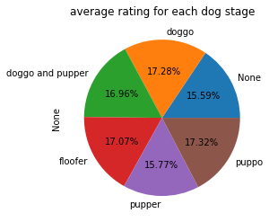

```python
# ploting in a pie chart
import matplotlib.pyplot as plt
import seaborn as sns
%matplotlib inline

average(total, count).plot(kind = 'pie', autopct = '%.2f%%')
plt.title('average rating for each dog stage');
```

It was a fierce battle between puppo and doggo but somehow and I repeat, somehow, puppo managed to win. It was almost a tie

#### Which dog breed had the highest rating ( rating agaisnt dog breeds)

```python
tam.dog_breeds.unique()
```

```
array(['chihuahua', 'basset', 'chesapeake_bay_retriever', 'appenzeller',
       'pomeranian', 'irish_terrier', 'pembroke', 'samoyed',
       'french_bulldog', 'golden_retriever', 'whippet', 'siberian_husky',
       'mexican_hairless', 'kuvasz', 'pug', 'blenheim_spaniel',
       'malamute', 'italian_greyhound', 'chow', 'german_shepherd',
       'doberman', 'eskimo_dog', 'labrador_retriever', 'weimaraner',
       'saluki', 'miniature_pinscher', 'german_short-haired_pointer',
       'english_springer', 'vizsla', 'bloodhound', 'bernese_mountain_dog',
       'west_highland_white_terrier', 'cocker_spaniel',
       'flat-coated_retriever', 'cardigan', 'newfoundland',
       'shetland_sheepdog', 'komondor', 'kelpie',
       'greater_swiss_mountain_dog', 'border_collie', 'bull_mastiff',
       'staffordshire_bullterrier', 'lakeland_terrier',
       'australian_terrier', 'bedlington_terrier', 'boston_bull',
       'old_english_sheepdog', 'black-and-tan_coonhound', 'great_dane',
       'yorkshire_terrier', 'schipperke', 'airedale', 'giant_schnauzer',
       'dandie_dinmont', 'irish_water_spaniel', 'afghan_hound',
       'brittany_spaniel', 'leonberg', 'border_terrier', 'great_pyrenees',
       'norwegian_elkhound', 'american_staffordshire_terrier', 'borzoi',
       'rottweiler', 'rhodesian_ridgeback', 'boxer', 'pekinese', 'briard',
       'toy_poodle', 'collie', 'english_setter', 'cairn', 'malinois',
       'irish_setter', 'gordon_setter', 'standard_poodle',
       'miniature_schnauzer', 'curly-coated_retriever', 'tibetan_mastiff',
       'dalmatian', 'miniature_poodle', 'beagle', 'toy_terrier',
       'norwich_terrier', 'norfolk_terrier', 'wire-haired_fox_terrier',
       'saint_bernard', 'walker_hound', 'silky_terrier', 'papillon',
       'basenji', 'keeshond', 'redbone', 'welsh_springer_spaniel',
       'sussex_spaniel', 'bluetick', 'shih-tzu', 'tibetan_terrier',
       'maltese_dog', 'lhasa', 'soft-coated_wheaten_terrier',
       'groenendael', 'scottish_deerhound', 'scotch_terrier',
       'ibizan_hound', 'entlebucher', 'japanese_spaniel',
       'standard_schnauzer', 'brabancon_griffon'], dtype=object)
```

```python
# the count of unique value in the dog_breed column
tam.dog_breeds.value_counts().head(20)
```

```
golden_retriever             135
labrador_retriever            92
pembroke                      88
chihuahua                     79
pug                           54
chow                          41
samoyed                       40
toy_poodle                    38
pomeranian                    37
malamute                      29
cocker_spaniel                27
french_bulldog                26
chesapeake_bay_retriever      23
miniature_pinscher            22
german_shepherd               20
siberian_husky                19
staffordshire_bullterrier     19
maltese_dog                   18
shetland_sheepdog             18
eskimo_dog                    18
Name: dog_breeds, dtype: int64
```

```python
# each dog_breed and the sum of its rating
tam.groupby('dog_breeds').sum()['rating_num'].sort_values().head(20)
```

```
dog_breeds
japanese_spaniel            5
scotch_terrier              9
groenendael                10
entlebucher                11
standard_schnauzer         12
silky_terrier              12
black-and-tan_coonhound    21
toy_terrier                22
appenzeller                22
sussex_spaniel             22
australian_terrier         23
wire-haired_fox_terrier    23
welsh_springer_spaniel     27
ibizan_hound               27
afghan_hound               29
brabancon_griffon          30
curly-coated_retriever     31
scottish_deerhound         31
komondor                   33
cairn                      33
Name: rating_num, dtype: int32
```

```python
#calculating the average rating for each dog breed
total_breed = tam.groupby('dog_breeds').sum()['rating_num'].sort_values()
count_breed = tam.dog_breeds.value_counts()
average(total_breed, count_breed).sort_values(ascending = False). head(20)
```

```
saluki                     12.500000
briard                     12.333333
tibetan_mastiff            12.250000
border_terrier             12.142857
standard_schnauzer         12.000000
silky_terrier              12.000000
giant_schnauzer            12.000000
eskimo_dog                 11.777778
irish_setter               11.750000
gordon_setter              11.750000
samoyed                    11.700000
golden_retriever           11.622222
chow                       11.609756
cardigan                   11.529412
wire-haired_fox_terrier    11.500000
australian_terrier         11.500000
great_pyrenees             11.461538
kelpie                     11.454545
pembroke                   11.443182
norfolk_terrier            11.428571
dtype: float64
```

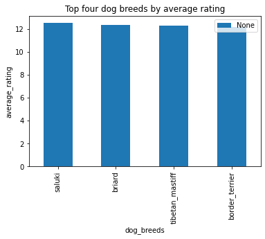

```python
# visualizing in a bar_chat
average(total_breed, count_breed).sort_values(ascending = False). head(4).plot(kind = 'bar')
plt.title('Top four dog breeds by average rating')
plt.legend()
plt.xlabel('dog_breeds')
plt.ylabel('average_rating');
```

And the Saluki dog breed has it! The dog breed with the highest average dog rating

#### The year with the highest average dog rating

```python
# checking for unique year
tam.timestamp.dt.year.unique()
```

```
array([2017, 2016, 2015], dtype=int64)
```

```python
# total rating by year
tam.groupby(tam.timestamp.dt.year).sum()['rating_num'].sort_values()
```

```
timestamp
2017    3603
2015    4300
2016    8043
Name: rating_num, dtype: int32
```

```python
#count of tweet per year
tam.groupby(tam.timestamp.dt.year).count()['tweet_id'].sort_values()
```

```
timestamp
2017    288
2015    436
2016    736
Name: tweet_id, dtype: int64
```

```python
# average dog rating by year
total_year = tam.groupby(tam.timestamp.dt.year).sum()['rating_num'].sort_values()
count_year = tam.groupby(tam.timestamp.dt.year).count()['tweet_id'].sort_values()
average(total_year, count_year).sort_values()
```

```
timestamp
2015     9.862385
2016    10.927989
2017    12.510417
dtype: float64
```

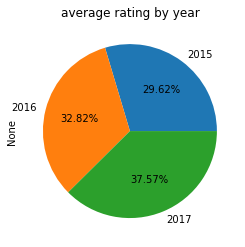

```python
#creating a visualization
average(total_year, count_year).sort_values().plot(kind = 'pie', autopct = '%.2f%%')
plt.title('average rating by year');
```

2017 is the year with the highest average dog rating

#### Number of tweet per year

```python
# checking for number of tweets by year
tam.groupby(tam.timestamp.dt.year).count()['tweet_id'].sort_values()
```

```
timestamp
2017    288
2015    436
2016    736
Name: tweet_id, dtype: int64
```

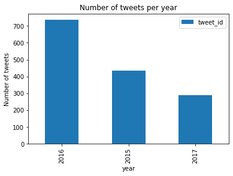

```python
# ploting a bar chart to represent it
tam.groupby(tam.timestamp.dt.year).count()['tweet_id'].sort_values(ascending = False).plot(kind = 'bar')
plt.title('Number of tweets per year')
plt.legend()
plt.xlabel('year')
plt.ylabel('Number of tweets');
```

The number of tweets by year saw an increase in 2016; from 436 in 2015 to 736 in 2016. But it decreased significantly in 2017 with 288 number of tweets. It could be that all the tweets from 2017 was not gathered

#### 2015 best dogs

1. by rating
2. by retweet
3. by favorited
4. overall

```python
#2015 best dog by rating
# creating a mask of tweets in 2015

dogs15 = tam[tam['timestamp'].dt.year == 2015]
```

```python
dogs15
```

|  | tweet_id | timestamp | text | name | rating_num | rating_den | dog_stages | jpg_url | dog_breeds | retweet_count | favorite_count |
| --- | --- | --- | --- | --- | --- | --- | --- | --- | --- | --- | --- |
| 1024 | 682662431982772225 | 2015-12-31 20:39:41+00:00 | Meet Joey and Izzy. Joey only has one ear that... | Joey | 11 | 10 | None | https://pbs.twimg.com/media/CXlN1-EWMAQdwXK.jpg | beagle | 1207 | 3326 |
| 1025 | 682638830361513985 | 2015-12-31 19:05:54+00:00 | I have no words. Just a magnificent pup. 12/10... | None | 12 | 10 | None | https://pbs.twimg.com/media/CXk4W0qWYAMEMEs.jpg | english_springer | 675 | 2266 |
| 1026 | 682429480204398592 | 2015-12-31 05:14:01+00:00 | I know we joke around on here, but this is get... | None | 8 | 10 | None | https://pbs.twimg.com/media/CXh5_dDWQAIbU-J.jpg | whippet | 1320 | 3769 |
| 1027 | 682393905736888321 | 2015-12-31 02:52:40+00:00 | This is Kreg. He's riding an invisible jet ski... | Kreg | 11 | 10 | None | https://pbs.twimg.com/media/CXhZom1UwAA4Zz6.jpg | vizsla | 773 | 2441 |
| 1028 | 682389078323662849 | 2015-12-31 02:33:29+00:00 | Meet Brody. He's a Downton Abbey Falsetto. Add... | Brody | 9 | 10 | None | https://pbs.twimg.com/media/CXhVKtvW8AAyiyK.jpg | curly-coated_retriever | 518 | 1828 |
| ... | ... | ... | ... | ... | ... | ... | ... | ... | ... | ... | ... |
| 1455 | 666049248165822465 | 2015-11-16 00:24:50+00:00 | Here we have a 1949 1st generation vulpix. Enj... | None | 5 | 10 | None | https://pbs.twimg.com/media/CT5IQmsXIAAKY4A.jpg | miniature_pinscher | 41 | 111 |
| 1456 | 666044226329800704 | 2015-11-16 00:04:52+00:00 | This is a purebred Piers Morgan. Loves to Netf... | None | 6 | 10 | None | https://pbs.twimg.com/media/CT5Dr8HUEAA-lEu.jpg | rhodesian_ridgeback | 147 | 311 |
| 1457 | 666033412701032449 | 2015-11-15 23:21:54+00:00 | Here is a very happy pup. Big fan of well-main... | None | 9 | 10 | None | https://pbs.twimg.com/media/CT4521TWwAEvMyu.jpg | german_shepherd | 47 | 128 |
| 1458 | 666029285002620928 | 2015-11-15 23:05:30+00:00 | This is a western brown Mitsubishi terrier. Up... | None | 7 | 10 | None | https://pbs.twimg.com/media/CT42GRgUYAA5iDo.jpg | redbone | 48 | 132 |
| 1459 | 666020888022790149 | 2015-11-15 22:32:08+00:00 | Here we have a Japanese Irish Setter. Lost eye... | None | 8 | 10 | None | https://pbs.twimg.com/media/CT4udn0WwAA0aMy.jpg | welsh_springer_spaniel | 532 | 2535 |

436 rows × 11 columns

```python
# the dog with the highest rating in 2015

dogs15[dogs15.rating_num == dogs15.rating_num.max()].count()
```

```
tweet_id          13
timestamp         13
text              13
name              13
rating_num        13
rating_den        13
dog_stages        13
jpg_url           13
dog_breeds        13
retweet_count     13
favorite_count    13
dtype: int64
```

There is no winner! There are 13 dogs with maximum rating of 13/10 in 2015

```python
# the dog tweet with the highest retweet

dogs15[dogs15.retweet_count == dogs15.retweet_count.max()]
```

|  | tweet_id | timestamp | text | name | rating_num | rating_den | dog_stages | jpg_url | dog_breeds | retweet_count | favorite_count |
| --- | --- | --- | --- | --- | --- | --- | --- | --- | --- | --- | --- |
| 1070 | 679462823135686656 | 2015-12-23 00:45:35+00:00 | Meet Hurley. He's the curly one. He hugs every... | Hurley | 11 | 10 | None | https://pbs.twimg.com/media/CW3v1KxW8AAIOuy.jpg | toy_poodle | 21324 | 34856 |

We have a winner here! Hurley, 2015 best dog by retweet with a retweet count of 21324

```python
# the dog tweet that is most favorited

dogs15[dogs15.favorite_count == dogs15.favorite_count.max()]
```

|  | tweet_id | timestamp | text | name | rating_num | rating_den | dog_stages | jpg_url | dog_breeds | retweet_count | favorite_count |
| --- | --- | --- | --- | --- | --- | --- | --- | --- | --- | --- | --- |
| 1414 | 667152164079423490 | 2015-11-19 01:27:25+00:00 | This is Pipsy. He is a fluffball. Enjoys trave... | Pipsy | 12 | 10 | None | https://pbs.twimg.com/media/CUIzWk_UwAAfUNq.jpg | toy_poodle | 18285 | 49720 |

We have a winner here! Pipsy, 2015 best dog by a favorited tweet count of 49720

```python
# the overall best dog for 2015
# creating a column that contains the sum of rating_num, favorite_count and retweet_count

dogs15['overall_rating'] = dogs15['rating_num'] + dogs15['retweet_count'] + dogs15['favorite_count']
dogs15
```

|  | tweet_id | timestamp | text | name | rating_num | rating_den | dog_stages | jpg_url | dog_breeds | retweet_count | favorite_count | overall_rating |
| --- | --- | --- | --- | --- | --- | --- | --- | --- | --- | --- | --- | --- |
| 1024 | 682662431982772225 | 2015-12-31 20:39:41+00:00 | Meet Joey and Izzy. Joey only has one ear that... | Joey | 11 | 10 | None | https://pbs.twimg.com/media/CXlN1-EWMAQdwXK.jpg | beagle | 1207 | 3326 | 4544 |
| 1025 | 682638830361513985 | 2015-12-31 19:05:54+00:00 | I have no words. Just a magnificent pup. 12/10... | None | 12 | 10 | None | https://pbs.twimg.com/media/CXk4W0qWYAMEMEs.jpg | english_springer | 675 | 2266 | 2953 |
| 1026 | 682429480204398592 | 2015-12-31 05:14:01+00:00 | I know we joke around on here, but this is get... | None | 8 | 10 | None | https://pbs.twimg.com/media/CXh5_dDWQAIbU-J.jpg | whippet | 1320 | 3769 | 5097 |
| 1027 | 682393905736888321 | 2015-12-31 02:52:40+00:00 | This is Kreg. He's riding an invisible jet ski... | Kreg | 11 | 10 | None | https://pbs.twimg.com/media/CXhZom1UwAA4Zz6.jpg | vizsla | 773 | 2441 | 3225 |
| 1028 | 682389078323662849 | 2015-12-31 02:33:29+00:00 | Meet Brody. He's a Downton Abbey Falsetto. Add... | Brody | 9 | 10 | None | https://pbs.twimg.com/media/CXhVKtvW8AAyiyK.jpg | curly-coated_retriever | 518 | 1828 | 2355 |
| ... | ... | ... | ... | ... | ... | ... | ... | ... | ... | ... | ... | ... |
| 1455 | 666049248165822465 | 2015-11-16 00:24:50+00:00 | Here we have a 1949 1st generation vulpix. Enj... | None | 5 | 10 | None | https://pbs.twimg.com/media/CT5IQmsXIAAKY4A.jpg | miniature_pinscher | 41 | 111 | 157 |
| 1456 | 666044226329800704 | 2015-11-16 00:04:52+00:00 | This is a purebred Piers Morgan. Loves to Netf... | None | 6 | 10 | None | https://pbs.twimg.com/media/CT5Dr8HUEAA-lEu.jpg | rhodesian_ridgeback | 147 | 311 | 464 |
| 1457 | 666033412701032449 | 2015-11-15 23:21:54+00:00 | Here is a very happy pup. Big fan of well-main... | None | 9 | 10 | None | https://pbs.twimg.com/media/CT4521TWwAEvMyu.jpg | german_shepherd | 47 | 128 | 184 |
| 1458 | 666029285002620928 | 2015-11-15 23:05:30+00:00 | This is a western brown Mitsubishi terrier. Up... | None | 7 | 10 | None | https://pbs.twimg.com/media/CT42GRgUYAA5iDo.jpg | redbone | 48 | 132 | 187 |
| 1459 | 666020888022790149 | 2015-11-15 22:32:08+00:00 | Here we have a Japanese Irish Setter. Lost eye... | None | 8 | 10 | None | https://pbs.twimg.com/media/CT4udn0WwAA0aMy.jpg | welsh_springer_spaniel | 532 | 2535 | 3075 |

436 rows × 12 columns

```python
#checking for the tweet with the maximum overall rating
dogs15[dogs15.overall_rating == dogs15.overall_rating.max()]
```

|  | tweet_id | timestamp | text | name | rating_num | rating_den | dog_stages | jpg_url | dog_breeds | retweet_count | favorite_count | overall_rating |
| --- | --- | --- | --- | --- | --- | --- | --- | --- | --- | --- | --- | --- |
| 1414 | 667152164079423490 | 2015-11-19 01:27:25+00:00 | This is Pipsy. He is a fluffball. Enjoys trave... | Pipsy | 12 | 10 | None | https://pbs.twimg.com/media/CUIzWk_UwAAfUNq.jpg | toy_poodle | 18285 | 49720 | 68017 |

And it's Pipsy! The overall best dog for the year 2015 with an overall rating of 68017

### 2016 best dogs

1. by rating
2. by retweet
3. by favorited
4. overall

```python
# creatng a mask of tweets in 2016
dogs16 = tam[tam.timestamp.dt.year == 2016]
```

```python
dogs16
```

|  | tweet_id | timestamp | text | name | rating_num | rating_den | dog_stages | jpg_url | dog_breeds | retweet_count | favorite_count |
| --- | --- | --- | --- | --- | --- | --- | --- | --- | --- | --- | --- |
| 288 | 814986499976527872 | 2016-12-31 00:08:17+00:00 | This is Cooper. Someone attacked him with a sh... | Cooper | 11 | 10 | pupper | https://pbs.twimg.com/media/C09p5dJWIAE5qKL.jpg | dalmatian | 1505 | 8485 |
| 289 | 814638523311648768 | 2016-12-30 01:05:33+00:00 | This is Olivia. She's a passionate advocate of... | Olivia | 12 | 10 | None | https://pbs.twimg.com/media/C04taUjWIAA6Mo4.jpg | golden_retriever | 3130 | 12511 |
| 290 | 814530161257443328 | 2016-12-29 17:54:58+00:00 | This is Alf. Someone just rubbed a balloon on ... | Alf | 12 | 10 | None | https://pbs.twimg.com/media/C03K2-VWIAAK1iV.jpg | miniature_poodle | 2156 | 9629 |
| 291 | 814153002265309185 | 2016-12-28 16:56:16+00:00 | This is Oshie. He's ready to party. Bought tha... | Oshie | 12 | 10 | None | https://pbs.twimg.com/media/C0xz04SVIAAeyDb.jpg | golden_retriever | 10080 | 32000 |
| 292 | 813910438903693312 | 2016-12-28 00:52:25+00:00 | This is Chubbs. He dug a hole and now he's stu... | Chubbs | 11 | 10 | doggo | https://pbs.twimg.com/media/C0uXObSXUAAIzmV.jpg | siberian_husky | 2194 | 10342 |
| ... | ... | ... | ... | ... | ... | ... | ... | ... | ... | ... | ... |
| 1019 | 683142553609318400 | 2016-01-02 04:27:31+00:00 | Meet Brandy. She's a member of the Bloods. Men... | Brandy | 9 | 10 | pupper | https://pbs.twimg.com/media/CXsChyjW8AQJ16C.jpg | leonberg | 1173 | 3162 |
| 1020 | 683111407806746624 | 2016-01-02 02:23:45+00:00 | This is Larry. He thought the New Year's parti... | Larry | 10 | 10 | pupper | https://pbs.twimg.com/media/CXrmMSpUwAAdeRj.jpg | cocker_spaniel | 1034 | 3736 |
| 1021 | 683098815881154561 | 2016-01-02 01:33:43+00:00 | aahhhhkslaldhwnxmzbbs 12/10 for being da smoos... | None | 12 | 10 | None | https://pbs.twimg.com/media/CXrawAhWkAAWSxC.jpg | golden_retriever | 736 | 2361 |
| 1022 | 683030066213818368 | 2016-01-01 21:00:32+00:00 | This is Lulu. She's contemplating all her unre... | Lulu | 10 | 10 | None | https://pbs.twimg.com/media/CXqcOHCUQAAugTB.jpg | boxer | 832 | 2370 |
| 1023 | 682750546109968385 | 2016-01-01 02:29:49+00:00 | Meet Taco. He's a speckled Garnier Fructis. Lo... | Taco | 9 | 10 | None | https://pbs.twimg.com/media/CXmd_bsWkAEEXck.jpg | english_setter | 494 | 1674 |

736 rows × 11 columns

```python
# dogs with the highest rating in 2016
dogs16[dogs16.rating_num == dogs16.rating_num.max()]
```

|  | tweet_id | timestamp | text | name | rating_num | rating_den | dog_stages | jpg_url | dog_breeds | retweet_count | favorite_count |
| --- | --- | --- | --- | --- | --- | --- | --- | --- | --- | --- | --- |
| 293 | 813812741911748608 | 2016-12-27 18:24:12+00:00 | Meet Gary, Carrie Fisher's dog. Idk what I can... | Gary | 14 | 10 | None | https://pbs.twimg.com/media/C0s-XtzWgAAp1W-.jpg | french_bulldog | 16267 | 40402 |
| 323 | 807621403335917568 | 2016-12-10 16:22:02+00:00 | This is Ollie Vue. He was a 3 legged pupper on... | Ollie | 14 | 10 | pupper | https://pbs.twimg.com/media/CzU_YVGUUAA3Xsd.jpg | golden_retriever | 4288 | 16236 |
| 441 | 778408200802557953 | 2016-09-21 01:39:11+00:00 | RIP Loki. Thank you for the good times. You wi... | None | 14 | 10 | None | https://pbs.twimg.com/media/Cs12ICuWAAECNRy.jpg | pembroke | 5023 | 15135 |
| 458 | 774314403806253056 | 2016-09-09 18:31:54+00:00 | I WAS SENT THE ACTUAL DOG IN THE PROFILE PIC B... | None | 14 | 10 | None | https://pbs.twimg.com/media/Cr7q1VxWIAA5Nm7.jpg | eskimo_dog | 6478 | 24167 |

There are four winners! with maximum rating of 14/10

```python
# dog tweet with the highest number of retweet counts

dogs16[dogs16.retweet_count == dogs16.retweet_count.max()]
```

|  | tweet_id | timestamp | text | name | rating_num | rating_den | dog_stages | jpg_url | dog_breeds | retweet_count | favorite_count |
| --- | --- | --- | --- | --- | --- | --- | --- | --- | --- | --- | --- |
| 612 | 744234799360020481 | 2016-06-18 18:26:18+00:00 | Here's a doggo realizing you can stand in a po... | None | 13 | 10 | doggo | https://pbs.twimg.com/ext_tw_video_thumb/74423... | labrador_retriever | 79515 | 131075 |

No name dog! with a retweet count of 79515

```python
#dog tweet with the highest number of favorite count

dogs16[dogs16.favorite_count == dogs16.favorite_count.max()]
```

|  | tweet_id | timestamp | text | name | rating_num | rating_den | dog_stages | jpg_url | dog_breeds | retweet_count | favorite_count |
| --- | --- | --- | --- | --- | --- | --- | --- | --- | --- | --- | --- |
| 612 | 744234799360020481 | 2016-06-18 18:26:18+00:00 | Here's a doggo realizing you can stand in a po... | None | 13 | 10 | doggo | https://pbs.twimg.com/ext_tw_video_thumb/74423... | labrador_retriever | 79515 | 131075 |

Wow! No name dog again, now with a favorite_count of 131075

```python
# the overall best dog of the year, 2016
#creating the overall rating column
dogs16['overall_rating'] = dogs16['rating_num'] + dogs16['retweet_count'] + dogs16['favorite_count']

#getting the overall dog of the year
dogs16[dogs16.overall_rating == dogs16.overall_rating.max()]
```

|  | tweet_id | timestamp | text | name | rating_num | rating_den | dog_stages | jpg_url | dog_breeds | retweet_count | favorite_count | overall_rating |
| --- | --- | --- | --- | --- | --- | --- | --- | --- | --- | --- | --- | --- |
| 612 | 744234799360020481 | 2016-06-18 18:26:18+00:00 | Here's a doggo realizing you can stand in a po... | None | 13 | 10 | doggo | https://pbs.twimg.com/ext_tw_video_thumb/74423... | labrador_retriever | 79515 | 131075 | 210603 |

And you guessed it! The same No name dog again! with an overall rating of 210603. A doggo and a labrador retriever

### 2017 best dogs

1. by rating
2. by retweet
3. by favorited
4. overall

```python
#creating a mask of dog tweets in 2017

dogs17 = tam[tam.timestamp.dt.year == 2017]
```

```python
dogs17
```

|  | tweet_id | timestamp | text | name | rating_num | rating_den | dog_stages | jpg_url | dog_breeds | retweet_count | favorite_count |
| --- | --- | --- | --- | --- | --- | --- | --- | --- | --- | --- | --- |
| 0 | 892177421306343426 | 2017-08-01 00:17:27+00:00 | This is Tilly. She's just checking pup on you.... | Tilly | 13 | 10 | None | https://pbs.twimg.com/media/DGGmoV4XsAAUL6n.jpg | chihuahua | 6514 | 33819 |
| 1 | 891815181378084864 | 2017-07-31 00:18:03+00:00 | This is Archie. He is a rare Norwegian Pouncin... | Archie | 12 | 10 | None | https://pbs.twimg.com/media/DGBdLU1WsAANxJ9.jpg | chihuahua | 4328 | 25461 |
| 2 | 891327558926688256 | 2017-07-29 16:00:24+00:00 | This is Franklin. He would like you to stop ca... | Franklin | 12 | 10 | None | https://pbs.twimg.com/media/DF6hr6BUMAAzZgT.jpg | basset | 9774 | 41048 |
| 3 | 891087950875897856 | 2017-07-29 00:08:17+00:00 | Here we have a majestic great white breaching ... | None | 13 | 10 | None | https://pbs.twimg.com/media/DF3HwyEWsAABqE6.jpg | chesapeake_bay_retriever | 3261 | 20562 |
| 4 | 890971913173991426 | 2017-07-28 16:27:12+00:00 | Meet Jax. He enjoys ice cream so much he gets ... | Jax | 13 | 10 | None | https://pbs.twimg.com/media/DF1eOmZXUAALUcq.jpg | appenzeller | 2158 | 12041 |
| ... | ... | ... | ... | ... | ... | ... | ... | ... | ... | ... | ... |
| 283 | 816091915477250048 | 2017-01-03 01:20:49+00:00 | This is Comet. He's a Wild Estonian Poofer. Su... | Comet | 12 | 10 | None | https://pbs.twimg.com/media/C1NXQ6NXUAEAxIQ.jpg | pomeranian | 2500 | 9927 |
| 284 | 815990720817401858 | 2017-01-02 18:38:42+00:00 | Meet Jack. He's one of the rare doggos that do... | Jack | 11 | 10 | None | https://pbs.twimg.com/media/C1L7OVVWQAIQ6Tt.jpg | chihuahua | 1207 | 5545 |
| 285 | 815966073409433600 | 2017-01-02 17:00:46+00:00 | Here's a pupper with squeaky hiccups. Please e... | None | 13 | 10 | pupper | https://pbs.twimg.com/ext_tw_video_thumb/81596... | tibetan_mastiff | 9907 | 25057 |
| 286 | 815736392542261248 | 2017-01-02 01:48:06+00:00 | This is Akumi. It's his birthday. He received ... | Akumi | 11 | 10 | None | https://pbs.twimg.com/media/C1IT6rVXUAIvwYT.jpg | border_collie | 2625 | 10937 |
| 287 | 815639385530101762 | 2017-01-01 19:22:38+00:00 | This is Titan. His nose is quite chilly. Reque... | Titan | 12 | 10 | None | https://pbs.twimg.com/media/C1G7sXyWIAA10eH.jpg | german_shepherd | 1918 | 9161 |

288 rows × 11 columns

```python
# best dogs by rating
dogs17[dogs17.rating_num == dogs17.rating_num.max()].count()
```

```
tweet_id          17
timestamp         17
text              17
name              17
rating_num        17
rating_den        17
dog_stages        17
jpg_url           17
dog_breeds        17
retweet_count     17
favorite_count    17
dtype: int64
```

Oops! there are 17 dogs with the highest rating. What a competition!

```python
# best dog by retweet counts for 2017

dogs17[dogs17.retweet_count == dogs17.retweet_count.max()]
```

|  | tweet_id | timestamp | text | name | rating_num | rating_den | dog_stages | jpg_url | dog_breeds | retweet_count | favorite_count |
| --- | --- | --- | --- | --- | --- | --- | --- | --- | --- | --- | --- |
| 249 | 822872901745569793 | 2017-01-21 18:26:02+00:00 | Here's a super supportive puppo participating ... | None | 13 | 10 | puppo | https://pbs.twimg.com/media/C2tugXLXgAArJO4.jpg | lakeland_terrier | 48265 | 132810 |

```python
# best dog by favourite count for 2018

dogs17[dogs17.favorite_count == dogs17.favorite_count.max()]
```

|  | tweet_id | timestamp | text | name | rating_num | rating_den | dog_stages | jpg_url | dog_breeds | retweet_count | favorite_count |
| --- | --- | --- | --- | --- | --- | --- | --- | --- | --- | --- | --- |
| 249 | 822872901745569793 | 2017-01-21 18:26:02+00:00 | Here's a super supportive puppo participating ... | None | 13 | 10 | puppo | https://pbs.twimg.com/media/C2tugXLXgAArJO4.jpg | lakeland_terrier | 48265 | 132810 |

```python
# 2017 overall best dog
#creating the overall_rating column
dogs17['overall_rating'] = dogs17['rating_num'] + dogs17['retweet_count'] + dogs17['favorite_count']


#getting the overall dog of the year
dogs17[dogs17.overall_rating == dogs17.overall_rating.max()]
```

|  | tweet_id | timestamp | text | name | rating_num | rating_den | dog_stages | jpg_url | dog_breeds | retweet_count | favorite_count | overall_rating |
| --- | --- | --- | --- | --- | --- | --- | --- | --- | --- | --- | --- | --- |
| 249 | 822872901745569793 | 2017-01-21 18:26:02+00:00 | Here's a super supportive puppo participating ... | None | 13 | 10 | puppo | https://pbs.twimg.com/media/C2tugXLXgAArJO4.jpg | lakeland_terrier | 48265 | 132810 | 181088 |

Oh yes! it is the same lakelan terrier. An outstanding puppo with an overall rating of 181088, loved and cherished by others

### Insights:

1. And it's Pipsy! The overall best dog for the year 2015 with an overall rating of 68017
2. And you guessed it! The same No name dog again! with an overall rating of 210603. A doggo and a labrador retriever is the overall best dog for 2016
3. Oh yes! it is the same lakelan terrier. An outstanding puppo with an overall rating of 181088, loved and cherished by others is the overall best dog for 2017
4. The number of tweets by year saw an increase in 2016; from 436 in 2015 to 736 in 2016. But it decreased significantly in 2017 with 288 number of tweets. It could be that all the tweets from 2017 was not gathered
5. 2017 is the year with the highest average dog rating
6. And the Saluki dog breed has it! The dog breed with the highest average dog rating
7. The dog stage with the highest average rating. It was a fierce battle between puppo and doggo but somehow and I repeat, somehow, puppo managed to win. It was almost a tie

### Visualization

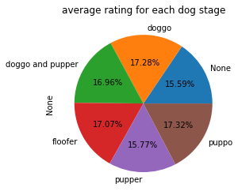

```python
# ploting in a pie chart
average(total, count).plot(kind = 'pie', autopct = '%.2f%%')
plt.title('average rating for each dog stage');
```

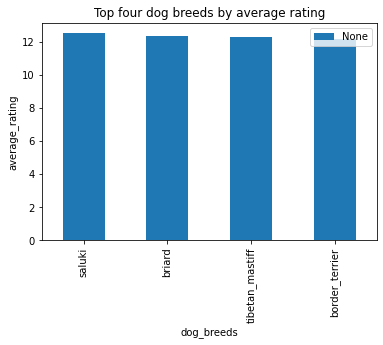

```python
# visualizing in a bar_chat
average(total_breed, count_breed).sort_values(ascending = False). head(4).plot(kind = 'bar')
plt.title('Top four dog breeds by average rating')
plt.legend()
plt.xlabel('dog_breeds')
plt.ylabel('average_rating');
```